# Part I - Bike-sharing Data Exploration

## by Oluyimika Sosanya

## Introduction

> This document explores a dataset which containing duration and other attributes for approximately 2,410,000 individual rides made in a bike-sharing system covering the greater San Francisco Bay area in 2019. The goal of my analysis is to answer the following questions:
> 1. *How long does the average trip take?*
> 2. *Does average trip duration depend on user type?*
> 3. *When are most trips taken in terms of time of day, day of the week, or month of the year?*

## Table of Content

#### Preliminary Wrangling

#### Dataset Overview

#### Univariate Exploration

#### Bivariate Exploration

#### Multivariate Exploration

#### Conclusions

## Preliminary Wrangling

```python
# import all packages and set plots to be embedded inline
import numpy as np
import pandas as pd
import matplotlib.pyplot as plt
import seaborn as sb
import os
import requests
import zipfile
from datetime import datetime

%matplotlib inline
```

> Load in your dataset and describe its properties through the questions below. Try and motivate your exploration goals through this section.

```python
filePath = 'c:/datasets'

# Use OS to make directory if it doesn't exist
if not os.path.exists(filePath):
    os.makedirs(filePath)
```

```python
# Create a list of urls for a full year coverage
bikeShareUrls = ['https://s3.amazonaws.com/baywheels-data/201901-fordgobike-tripdata.csv.zip',
                 'https://s3.amazonaws.com/baywheels-data/201902-fordgobike-tripdata.csv.zip',
                 'https://s3.amazonaws.com/baywheels-data/201903-fordgobike-tripdata.csv.zip',
                 'https://s3.amazonaws.com/baywheels-data/201904-fordgobike-tripdata.csv.zip',
                 'https://s3.amazonaws.com/baywheels-data/201905-baywheels-tripdata.csv.zip',
                 'https://s3.amazonaws.com/baywheels-data/201906-baywheels-tripdata.csv.zip',
                 'https://s3.amazonaws.com/baywheels-data/201907-baywheels-tripdata.csv.zip',
                 'https://s3.amazonaws.com/baywheels-data/201908-baywheels-tripdata.csv.zip',
                 'https://s3.amazonaws.com/baywheels-data/201909-baywheels-tripdata.csv.zip',
                 'https://s3.amazonaws.com/baywheels-data/201910-baywheels-tripdata.csv.zip',
                 'https://s3.amazonaws.com/baywheels-data/201911-baywheels-tripdata.csv.zip',
                 'https://s3.amazonaws.com/baywheels-data/201912-baywheels-tripdata.csv.zip']
```

```python
# Loop through url list to download data programatically using Requests
for url in bikeShareUrls:
    response = requests.get(url)
    # Save datafile into the directory
    with open(os.path.join(filePath, url.split('/')[-1]), mode='wb') as file:
        file.write(response.content)
```

```python
# Create a list to hold the full file directory of the downloaded Zip files
bikeShareZip = []
#Use for loop to extract file name from bikeShareUrls
for url in bikeShareUrls:
    zipFile = filePath + '/' + url.split('/')[-1]
    bikeShareZip.append(zipFile)

# Extract all the contents in the zip file into the working directory
for fileDir in bikeShareZip:
    with zipfile.ZipFile(fileDir, 'r') as myzip:
        myzip.extractall()
```

Load all data files into Pandas dataframes

```python
df_01 = pd.read_csv('201901-fordgobike-tripdata.csv')
df_02 = pd.read_csv('201902-fordgobike-tripdata.csv')
df_03 = pd.read_csv('201903-fordgobike-tripdata.csv')
df_04 = pd.read_csv('201904-fordgobike-tripdata.csv')
df_05 = pd.read_csv('201905-baywheels-tripdata.csv')
df_06 = pd.read_csv('201906-baywheels-tripdata.csv', low_memory=False)
df_07 = pd.read_csv('201907-baywheels-tripdata.csv', low_memory=False)
df_08 = pd.read_csv('201908-baywheels-tripdata.csv')
df_09 = pd.read_csv('201909-baywheels-tripdata.csv')
df_10 = pd.read_csv('201910-baywheels-tripdata.csv')
df_11 = pd.read_csv('201911-baywheels-tripdata.csv', low_memory=False)
df_12 = pd.read_csv('201912-baywheels-tripdata.csv', low_memory=False)
```

```python
print(df_01.shape)
print(df_01.info())
df_01.head(10)
```

```
(192082, 14)
<class 'pandas.core.frame.DataFrame'>
RangeIndex: 192082 entries, 0 to 192081
Data columns (total 14 columns):
 #   Column                   Non-Null Count   Dtype
---  ------                   --------------   -----
 0   duration_sec             192082 non-null  int64
 1   start_time               192082 non-null  object
 2   end_time                 192082 non-null  object
 3   start_station_id         191834 non-null  float64
 4   start_station_name       191834 non-null  object
 5   start_station_latitude   192082 non-null  float64
 6   start_station_longitude  192082 non-null  float64
 7   end_station_id           191834 non-null  float64
 8   end_station_name         191834 non-null  object
 9   end_station_latitude     192082 non-null  float64
 10  end_station_longitude    192082 non-null  float64
 11  bike_id                  192082 non-null  int64
 12  user_type                192082 non-null  object
 13  bike_share_for_all_trip  192082 non-null  object
dtypes: float64(6), int64(2), object(6)
memory usage: 20.5+ MB
None
```

|  | duration_sec | start_time | end_time | start_station_id | start_station_name | start_station_latitude | start_station_longitude | end_station_id | end_station_name | end_station_latitude | end_station_longitude | bike_id | user_type | bike_share_for_all_trip |
| --- | --- | --- | --- | --- | --- | --- | --- | --- | --- | --- | --- | --- | --- | --- |
| 0 | 80825 | 2019-01-31 17:57:44.6130 | 2019-02-01 16:24:49.8640 | 229.0 | Foothill Blvd at 42nd Ave | 37.775745 | -122.213037 | 196.0 | Grand Ave at Perkins St | 37.808894 | -122.256460 | 4861 | Subscriber | No |
| 1 | 65900 | 2019-01-31 20:58:33.8860 | 2019-02-01 15:16:54.1730 | 4.0 | Cyril Magnin St at Ellis St | 37.785881 | -122.408915 | 134.0 | Valencia St at 24th St | 37.752428 | -122.420628 | 5506 | Subscriber | No |
| 2 | 62633 | 2019-01-31 18:06:52.9240 | 2019-02-01 11:30:46.5300 | 245.0 | Downtown Berkeley BART | 37.870139 | -122.268422 | 157.0 | 65th St at Hollis St | 37.846784 | -122.291376 | 2717 | Customer | No |
| 3 | 44680 | 2019-01-31 19:46:09.7190 | 2019-02-01 08:10:50.3180 | 85.0 | Church St at Duboce Ave | 37.770083 | -122.429156 | 53.0 | Grove St at Divisadero | 37.775946 | -122.437777 | 4557 | Customer | No |
| 4 | 60709 | 2019-01-31 14:19:01.5410 | 2019-02-01 07:10:51.0650 | 16.0 | Steuart St at Market St | 37.794130 | -122.394430 | 28.0 | The Embarcadero at Bryant St | 37.787168 | -122.388098 | 2100 | Customer | No |
| 5 | 6733 | 2019-01-31 22:35:50.8130 | 2019-02-01 00:28:04.5120 | 245.0 | Downtown Berkeley BART | 37.870139 | -122.268422 | 266.0 | Parker St at Fulton St | 37.862464 | -122.264791 | 3532 | Subscriber | No |
| 6 | 1188 | 2019-01-31 23:54:38.9010 | 2019-02-01 00:14:27.9000 | 34.0 | Father Alfred E Boeddeker Park | 37.783988 | -122.412408 | 146.0 | 30th St at San Jose Ave | 37.742314 | -122.423181 | 5114 | Subscriber | No |
| 7 | 1254 | 2019-01-31 23:48:50.0920 | 2019-02-01 00:09:44.4970 | 318.0 | San Carlos St at Market St | 37.330698 | -121.888979 | 314.0 | Santa Clara St at Almaden Blvd | 37.333988 | -121.894902 | 3967 | Subscriber | No |
| 8 | 3153 | 2019-01-31 23:17:05.4620 | 2019-02-01 00:09:39.4570 | 29.0 | O'Farrell St at Divisadero St | 37.782405 | -122.439446 | 70.0 | Central Ave at Fell St | 37.773311 | -122.444293 | 4813 | Subscriber | No |
| 9 | 323 | 2019-01-31 23:59:47.5680 | 2019-02-01 00:05:11.1770 | 223.0 | 16th St Mission BART Station 2 | 37.764765 | -122.420091 | 129.0 | Harrison St at 20th St | 37.758862 | -122.412544 | 1976 | Subscriber | No |

```python
df_01.duplicated().sum()
```

```
0
```

```python
print(df_02.shape)
print(df_02.info())
df_02.head(10)
```

```
(183412, 14)
<class 'pandas.core.frame.DataFrame'>
RangeIndex: 183412 entries, 0 to 183411
Data columns (total 14 columns):
 #   Column                   Non-Null Count   Dtype
---  ------                   --------------   -----
 0   duration_sec             183412 non-null  int64
 1   start_time               183412 non-null  object
 2   end_time                 183412 non-null  object
 3   start_station_id         183215 non-null  float64
 4   start_station_name       183215 non-null  object
 5   start_station_latitude   183412 non-null  float64
 6   start_station_longitude  183412 non-null  float64
 7   end_station_id           183215 non-null  float64
 8   end_station_name         183215 non-null  object
 9   end_station_latitude     183412 non-null  float64
 10  end_station_longitude    183412 non-null  float64
 11  bike_id                  183412 non-null  int64
 12  user_type                183412 non-null  object
 13  bike_share_for_all_trip  183412 non-null  object
dtypes: float64(6), int64(2), object(6)
memory usage: 19.6+ MB
None
```

|  | duration_sec | start_time | end_time | start_station_id | start_station_name | start_station_latitude | start_station_longitude | end_station_id | end_station_name | end_station_latitude | end_station_longitude | bike_id | user_type | bike_share_for_all_trip |
| --- | --- | --- | --- | --- | --- | --- | --- | --- | --- | --- | --- | --- | --- | --- |
| 0 | 52185 | 2019-02-28 17:32:10.1450 | 2019-03-01 08:01:55.9750 | 21.0 | Montgomery St BART Station (Market St at 2nd St) | 37.789625 | -122.400811 | 13.0 | Commercial St at Montgomery St | 37.794231 | -122.402923 | 4902 | Customer | No |
| 1 | 42521 | 2019-02-28 18:53:21.7890 | 2019-03-01 06:42:03.0560 | 23.0 | The Embarcadero at Steuart St | 37.791464 | -122.391034 | 81.0 | Berry St at 4th St | 37.775880 | -122.393170 | 2535 | Customer | No |
| 2 | 61854 | 2019-02-28 12:13:13.2180 | 2019-03-01 05:24:08.1460 | 86.0 | Market St at Dolores St | 37.769305 | -122.426826 | 3.0 | Powell St BART Station (Market St at 4th St) | 37.786375 | -122.404904 | 5905 | Customer | No |
| 3 | 36490 | 2019-02-28 17:54:26.0100 | 2019-03-01 04:02:36.8420 | 375.0 | Grove St at Masonic Ave | 37.774836 | -122.446546 | 70.0 | Central Ave at Fell St | 37.773311 | -122.444293 | 6638 | Subscriber | No |
| 4 | 1585 | 2019-02-28 23:54:18.5490 | 2019-03-01 00:20:44.0740 | 7.0 | Frank H Ogawa Plaza | 37.804562 | -122.271738 | 222.0 | 10th Ave at E 15th St | 37.792714 | -122.248780 | 4898 | Subscriber | Yes |
| 5 | 1793 | 2019-02-28 23:49:58.6320 | 2019-03-01 00:19:51.7600 | 93.0 | 4th St at Mission Bay Blvd S | 37.770407 | -122.391198 | 323.0 | Broadway at Kearny | 37.798014 | -122.405950 | 5200 | Subscriber | No |
| 6 | 1147 | 2019-02-28 23:55:35.1040 | 2019-03-01 00:14:42.5880 | 300.0 | Palm St at Willow St | 37.317298 | -121.884995 | 312.0 | San Jose Diridon Station | 37.329732 | -121.901782 | 3803 | Subscriber | No |
| 7 | 1615 | 2019-02-28 23:41:06.7660 | 2019-03-01 00:08:02.7560 | 10.0 | Washington St at Kearny St | 37.795393 | -122.404770 | 127.0 | Valencia St at 21st St | 37.756708 | -122.421025 | 6329 | Subscriber | No |
| 8 | 1570 | 2019-02-28 23:41:48.7900 | 2019-03-01 00:07:59.7150 | 10.0 | Washington St at Kearny St | 37.795393 | -122.404770 | 127.0 | Valencia St at 21st St | 37.756708 | -122.421025 | 6548 | Subscriber | No |
| 9 | 1049 | 2019-02-28 23:49:47.6990 | 2019-03-01 00:07:17.0250 | 19.0 | Post St at Kearny St | 37.788975 | -122.403452 | 121.0 | Mission Playground | 37.759210 | -122.421339 | 6488 | Subscriber | No |

```python
df_02.duplicated().sum()
```

```
0
```

```python
print(df_03.shape)
print(df_03.info())
df_03.head(10)
```

```
(256299, 14)
<class 'pandas.core.frame.DataFrame'>
RangeIndex: 256299 entries, 0 to 256298
Data columns (total 14 columns):
 #   Column                   Non-Null Count   Dtype
---  ------                   --------------   -----
 0   duration_sec             256299 non-null  int64
 1   start_time               256299 non-null  object
 2   end_time                 256299 non-null  object
 3   start_station_id         256078 non-null  float64
 4   start_station_name       256078 non-null  object
 5   start_station_latitude   256299 non-null  float64
 6   start_station_longitude  256299 non-null  float64
 7   end_station_id           256078 non-null  float64
 8   end_station_name         256078 non-null  object
 9   end_station_latitude     256299 non-null  float64
 10  end_station_longitude    256299 non-null  float64
 11  bike_id                  256299 non-null  int64
 12  user_type                256299 non-null  object
 13  bike_share_for_all_trip  256299 non-null  object
dtypes: float64(6), int64(2), object(6)
memory usage: 27.4+ MB
None
```

|  | duration_sec | start_time | end_time | start_station_id | start_station_name | start_station_latitude | start_station_longitude | end_station_id | end_station_name | end_station_latitude | end_station_longitude | bike_id | user_type | bike_share_for_all_trip |
| --- | --- | --- | --- | --- | --- | --- | --- | --- | --- | --- | --- | --- | --- | --- |
| 0 | 53588 | 2019-03-31 20:59:21.8780 | 2019-04-01 11:52:30.2000 | 377.0 | Fell St at Stanyan St | 37.771917 | -122.453704 | 377.0 | Fell St at Stanyan St | 37.771917 | -122.453704 | 6803 | Subscriber | No |
| 1 | 74305 | 2019-03-31 13:56:46.0050 | 2019-04-01 10:35:11.4540 | 385.0 | Woolsey St at Sacramento St | 37.850578 | -122.278175 | 233.0 | 4th Ave at E 12th St (Temporary Location) | 37.795913 | -122.255547 | 6415 | Subscriber | No |
| 2 | 79789 | 2019-03-31 11:48:34.2010 | 2019-04-01 09:58:23.8240 | 3.0 | Powell St BART Station (Market St at 4th St) | 37.786375 | -122.404904 | 345.0 | Hubbell St at 16th St | 37.766483 | -122.398279 | 2317 | Customer | No |
| 3 | 59315 | 2019-03-31 16:48:54.3740 | 2019-04-01 09:17:30.1540 | 92.0 | Mission Bay Kids Park | 37.772301 | -122.393028 | 49.0 | S Park St at 3rd St | 37.780760 | -122.394989 | 6631 | Customer | No |
| 4 | 47886 | 2019-03-31 19:54:24.1480 | 2019-04-01 09:12:30.8170 | 339.0 | Jackson St at 11th St | 37.800002 | -122.266438 | 18.0 | Telegraph Ave at Alcatraz Ave | 37.850222 | -122.260172 | 5241 | Subscriber | No |
| 5 | 67439 | 2019-03-31 14:07:39.7160 | 2019-04-01 08:51:39.0340 | 195.0 | Bay Pl at Vernon St | 37.812314 | -122.260779 | 212.0 | Mosswood Park | 37.824893 | -122.260437 | 5118 | Customer | No |
| 6 | 77996 | 2019-03-31 11:04:34.2090 | 2019-04-01 08:44:30.7300 | 96.0 | Dolores St at 15th St | 37.766210 | -122.426614 | 134.0 | Valencia St at 24th St | 37.752428 | -122.420628 | 2630 | Customer | No |
| 7 | 51522 | 2019-03-31 18:20:44.5900 | 2019-04-01 08:39:26.9230 | 3.0 | Powell St BART Station (Market St at 4th St) | 37.786375 | -122.404904 | 3.0 | Powell St BART Station (Market St at 4th St) | 37.786375 | -122.404904 | 817 | Customer | No |
| 8 | 47140 | 2019-03-31 18:37:04.2230 | 2019-04-01 07:42:44.5640 | 381.0 | 20th St at Dolores St | 37.758238 | -122.426094 | 223.0 | 16th St Mission BART Station 2 | 37.764765 | -122.420091 | 4852 | Customer | No |
| 9 | 58462 | 2019-03-31 15:26:49.9150 | 2019-04-01 07:41:12.6750 | 34.0 | Father Alfred E Boeddeker Park | 37.783988 | -122.412408 | 34.0 | Father Alfred E Boeddeker Park | 37.783988 | -122.412408 | 5826 | Subscriber | Yes |

```python
df_03.duplicated().sum()
```

```
0
```

```python
print(df_04.shape)
print(df_04.info())
df_04.head(10)
```

```
(239111, 14)
<class 'pandas.core.frame.DataFrame'>
RangeIndex: 239111 entries, 0 to 239110
Data columns (total 14 columns):
 #   Column                   Non-Null Count   Dtype
---  ------                   --------------   -----
 0   duration_sec             239111 non-null  int64
 1   start_time               239111 non-null  object
 2   end_time                 239111 non-null  object
 3   start_station_id         239047 non-null  float64
 4   start_station_name       239047 non-null  object
 5   start_station_latitude   239111 non-null  float64
 6   start_station_longitude  239111 non-null  float64
 7   end_station_id           239047 non-null  float64
 8   end_station_name         239047 non-null  object
 9   end_station_latitude     239111 non-null  float64
 10  end_station_longitude    239111 non-null  float64
 11  bike_id                  239111 non-null  int64
 12  user_type                239111 non-null  object
 13  bike_share_for_all_trip  239111 non-null  object
dtypes: float64(6), int64(2), object(6)
memory usage: 25.5+ MB
None
```

|  | duration_sec | start_time | end_time | start_station_id | start_station_name | start_station_latitude | start_station_longitude | end_station_id | end_station_name | end_station_latitude | end_station_longitude | bike_id | user_type | bike_share_for_all_trip |
| --- | --- | --- | --- | --- | --- | --- | --- | --- | --- | --- | --- | --- | --- | --- |
| 0 | 50305 | 2019-04-30 22:33:55.1550 | 2019-05-01 12:32:20.4540 | 368.0 | Myrtle St at Polk St | 37.785434 | -122.419622 | 324.0 | Union Square (Powell St at Post St) | 37.788300 | -122.408531 | 2749 | Subscriber | No |
| 1 | 53725 | 2019-04-30 20:43:41.6320 | 2019-05-01 11:39:06.9170 | 246.0 | Berkeley Civic Center | 37.869060 | -122.270556 | 241.0 | Ashby BART Station | 37.852477 | -122.270213 | 2608 | Customer | No |
| 2 | 78072 | 2019-04-30 10:32:46.4890 | 2019-05-01 08:13:58.9750 | 64.0 | 5th St at Brannan St | 37.776754 | -122.399018 | 64.0 | 5th St at Brannan St | 37.776754 | -122.399018 | 258 | Subscriber | No |
| 3 | 78969 | 2019-04-30 10:00:51.5500 | 2019-05-01 07:57:01.2620 | 67.0 | San Francisco Caltrain Station 2 (Townsend St... | 37.776639 | -122.395526 | 89.0 | Division St at Potrero Ave | 37.769218 | -122.407646 | 1974 | Subscriber | No |
| 4 | 1128 | 2019-04-30 23:59:04.7390 | 2019-05-01 00:17:53.0910 | 124.0 | 19th St at Florida St | 37.760447 | -122.410807 | 5.0 | Powell St BART Station (Market St at 5th St) | 37.783899 | -122.408445 | 877 | Subscriber | No |
| 5 | 1388 | 2019-04-30 23:53:05.9820 | 2019-05-01 00:16:14.3130 | 243.0 | Bancroft Way at College Ave | 37.869360 | -122.254337 | 247.0 | Fulton St at Bancroft Way | 37.867789 | -122.265896 | 3234 | Customer | No |
| 6 | 920 | 2019-04-30 23:57:56.3400 | 2019-05-01 00:13:16.4540 | 202.0 | Washington St at 8th St | 37.800754 | -122.274894 | 220.0 | San Pablo Ave at MLK Jr Way | 37.811351 | -122.273422 | 3262 | Subscriber | Yes |
| 7 | 725 | 2019-04-30 23:56:11.2190 | 2019-05-01 00:08:16.9150 | 44.0 | Civic Center/UN Plaza BART Station (Market St ... | 37.781074 | -122.411738 | 121.0 | Mission Playground | 37.759210 | -122.421339 | 2706 | Customer | No |
| 8 | 488 | 2019-04-30 23:59:00.6600 | 2019-05-01 00:07:08.9750 | 21.0 | Montgomery St BART Station (Market St at 2nd St) | 37.789625 | -122.400811 | 64.0 | 5th St at Brannan St | 37.776754 | -122.399018 | 860 | Subscriber | No |
| 9 | 792 | 2019-04-30 23:53:37.6040 | 2019-05-01 00:06:50.4050 | 28.0 | The Embarcadero at Bryant St | 37.787168 | -122.388098 | 126.0 | Esprit Park | 37.761634 | -122.390648 | 896 | Subscriber | No |

```python
df_04.duplicated().sum()
```

```
0
```

```python
df4 = df_04[df_04.start_station_name.isnull()]
df4.start_station_latitude.value_counts()
```

```
37.40    35
37.41    18
37.39     6
37.42     2
37.38     2
37.36     1
Name: start_station_latitude, dtype: int64
```

```python
print(df_05.shape)
print(df_05.info())
df_05.head(10)
```

```
(182163, 14)
<class 'pandas.core.frame.DataFrame'>
RangeIndex: 182163 entries, 0 to 182162
Data columns (total 14 columns):
 #   Column                   Non-Null Count   Dtype
---  ------                   --------------   -----
 0   duration_sec             182163 non-null  int64
 1   start_time               182163 non-null  object
 2   end_time                 182163 non-null  object
 3   start_station_id         182148 non-null  float64
 4   start_station_name       182148 non-null  object
 5   start_station_latitude   182163 non-null  float64
 6   start_station_longitude  182163 non-null  float64
 7   end_station_id           182148 non-null  float64
 8   end_station_name         182148 non-null  object
 9   end_station_latitude     182163 non-null  float64
 10  end_station_longitude    182163 non-null  float64
 11  bike_id                  182163 non-null  int64
 12  user_type                182163 non-null  object
 13  bike_share_for_all_trip  182163 non-null  object
dtypes: float64(6), int64(2), object(6)
memory usage: 19.5+ MB
None
```

|  | duration_sec | start_time | end_time | start_station_id | start_station_name | start_station_latitude | start_station_longitude | end_station_id | end_station_name | end_station_latitude | end_station_longitude | bike_id | user_type | bike_share_for_all_trip |
| --- | --- | --- | --- | --- | --- | --- | --- | --- | --- | --- | --- | --- | --- | --- |
| 0 | 48877 | 2019-05-31 20:34:56.8110 | 2019-06-01 10:09:34.7960 | 321.0 | 5th St at Folsom | 37.780146 | -122.403071 | 60.0 | 8th St at Ringold St | 37.774520 | -122.409449 | 1416 | Customer | No |
| 1 | 47050 | 2019-05-31 19:43:56.1960 | 2019-06-01 08:48:06.9190 | 246.0 | Berkeley Civic Center | 37.869060 | -122.270556 | 266.0 | Parker St at Fulton St | 37.862464 | -122.264791 | 1797 | Subscriber | No |
| 2 | 5912 | 2019-05-31 23:54:24.0890 | 2019-06-01 01:32:56.9820 | 149.0 | Emeryville Town Hall | 37.831275 | -122.285633 | 149.0 | Emeryville Town Hall | 37.831275 | -122.285633 | 3612 | Customer | No |
| 3 | 2629 | 2019-05-31 23:59:57.4490 | 2019-06-01 00:43:46.8740 | 186.0 | Lakeside Dr at 14th St | 37.801319 | -122.262642 | 186.0 | Lakeside Dr at 14th St | 37.801319 | -122.262642 | 2333 | Customer | No |
| 4 | 4235 | 2019-05-31 23:05:48.9320 | 2019-06-01 00:16:24.4570 | 34.0 | Father Alfred E Boeddeker Park | 37.783988 | -122.412408 | 368.0 | Myrtle St at Polk St | 37.785434 | -122.419622 | 181 | Subscriber | No |
| 5 | 2954 | 2019-05-31 23:26:52.8120 | 2019-06-01 00:16:07.7250 | 50.0 | 2nd St at Townsend St | 37.780526 | -122.390288 | 6.0 | The Embarcadero at Sansome St | 37.804770 | -122.403234 | 3264 | Customer | No |
| 6 | 3071 | 2019-05-31 23:24:40.2500 | 2019-06-01 00:15:51.3030 | 50.0 | 2nd St at Townsend St | 37.780526 | -122.390288 | 6.0 | The Embarcadero at Sansome St | 37.804770 | -122.403234 | 1566 | Customer | No |
| 7 | 924 | 2019-05-31 23:58:16.1120 | 2019-06-01 00:13:40.5880 | 324.0 | Union Square (Powell St at Post St) | 37.788300 | -122.408531 | 50.0 | 2nd St at Townsend St | 37.780526 | -122.390288 | 1649 | Subscriber | No |
| 8 | 696 | 2019-05-31 23:57:58.1300 | 2019-06-01 00:09:35.0770 | 22.0 | Howard St at Beale St | 37.789756 | -122.394643 | 81.0 | Berry St at 4th St | 37.775880 | -122.393170 | 2832 | Subscriber | No |
| 9 | 510 | 2019-05-31 23:54:52.5790 | 2019-06-01 00:03:23.3450 | 211.0 | Broadway at 40th St | 37.827757 | -122.256716 | 181.0 | Grand Ave at Webster St | 37.811377 | -122.265192 | 81 | Subscriber | Yes |

```python
df_05.duplicated().sum()
```

```
0
```

```python
df5 = df_05[df_05.start_station_name.isnull()]
df5.start_station_latitude.value_counts()
```

```
37.41    5
37.42    4
37.40    3
37.39    2
37.38    1
Name: start_station_latitude, dtype: int64
```

```python
print(df_06.shape)
print(df_06.info())
df_06.head(10)
```

```
(191772, 15)
<class 'pandas.core.frame.DataFrame'>
RangeIndex: 191772 entries, 0 to 191771
Data columns (total 15 columns):
 #   Column                   Non-Null Count   Dtype
---  ------                   --------------   -----
 0   duration_sec             191772 non-null  int64
 1   start_time               191772 non-null  object
 2   end_time                 191772 non-null  object
 3   start_station_id         189612 non-null  float64
 4   start_station_name       189612 non-null  object
 5   start_station_latitude   191772 non-null  float64
 6   start_station_longitude  191772 non-null  float64
 7   end_station_id           189510 non-null  float64
 8   end_station_name         189510 non-null  object
 9   end_station_latitude     191772 non-null  float64
 10  end_station_longitude    191772 non-null  float64
 11  bike_id                  191772 non-null  int64
 12  user_type                191772 non-null  object
 13  bike_share_for_all_trip  187879 non-null  object
 14  rental_access_method     3893 non-null    object
dtypes: float64(6), int64(2), object(7)
memory usage: 21.9+ MB
None
```

|  | duration_sec | start_time | end_time | start_station_id | start_station_name | start_station_latitude | start_station_longitude | end_station_id | end_station_name | end_station_latitude | end_station_longitude | bike_id | user_type | bike_share_for_all_trip | rental_access_method |
| --- | --- | --- | --- | --- | --- | --- | --- | --- | --- | --- | --- | --- | --- | --- | --- |
| 0 | 81695 | 2019-06-30 18:16:09.7730 | 2019-07-01 16:57:45.5920 | 109.0 | 17th St at Valencia St | 37.763316 | -122.421904 | 56.0 | Koshland Park | 37.773414 | -122.427317 | 1502 | Subscriber | No | NaN |
| 1 | 74260 | 2019-06-30 18:09:55.8300 | 2019-07-01 14:47:36.6810 | 50.0 | 2nd St at Townsend St | 37.780526 | -122.390288 | 101.0 | 15th St at Potrero Ave | 37.767079 | -122.407359 | 2526 | Customer | No | NaN |
| 2 | 59603 | 2019-06-30 15:40:31.0380 | 2019-07-01 08:13:54.3490 | 23.0 | The Embarcadero at Steuart St | 37.791464 | -122.391034 | 30.0 | San Francisco Caltrain (Townsend St at 4th St) | 37.776598 | -122.395282 | 2427 | Subscriber | No | NaN |
| 3 | 67932 | 2019-06-30 12:49:47.7810 | 2019-07-01 07:42:00.5430 | 169.0 | Bushrod Park | 37.846516 | -122.265304 | 248.0 | Telegraph Ave at Ashby Ave | 37.855956 | -122.259795 | 1261 | Customer | No | NaN |
| 4 | 48894 | 2019-06-30 17:21:00.0550 | 2019-07-01 06:55:54.9960 | 15.0 | San Francisco Ferry Building (Harry Bridges Pl... | 37.795392 | -122.394203 | 30.0 | San Francisco Caltrain (Townsend St at 4th St) | 37.776598 | -122.395282 | 1070 | Customer | No | NaN |
| 5 | 47409 | 2019-06-30 16:47:22.3290 | 2019-07-01 05:57:32.0720 | 340.0 | Harmon St at Adeline St | 37.849735 | -122.270582 | 189.0 | Genoa St at 55th St | 37.839649 | -122.271756 | 2966 | Subscriber | No | NaN |
| 6 | 37282 | 2019-06-30 14:31:39.5730 | 2019-07-01 00:53:02.2520 | 6.0 | The Embarcadero at Sansome St | 37.804770 | -122.403234 | 400.0 | Buchanan St at North Point St | 37.804272 | -122.433537 | 1980 | Customer | No | NaN |
| 7 | 11105 | 2019-06-30 21:28:07.3040 | 2019-07-01 00:33:12.6240 | 377.0 | Fell St at Stanyan St | 37.771917 | -122.453704 | 380.0 | Masonic Ave at Turk St | 37.779047 | -122.447291 | 3515 | Subscriber | No | NaN |
| 8 | 27656 | 2019-06-30 16:50:35.4900 | 2019-07-01 00:31:32.4380 | 24.0 | Spear St at Folsom St | 37.789677 | -122.390428 | 370.0 | Jones St at Post St | 37.787327 | -122.413278 | 1836 | Customer | No | NaN |
| 9 | 1942 | 2019-06-30 23:48:21.5810 | 2019-07-01 00:20:44.4490 | 3.0 | Powell St BART Station (Market St at 4th St) | 37.786375 | -122.404904 | 16.0 | Steuart St at Market St | 37.794130 | -122.394430 | 1055 | Customer | No | NaN |

```python
df_06[df_06.rental_access_method.notnull()]
```

|  | duration_sec | start_time | end_time | start_station_id | start_station_name | start_station_latitude | start_station_longitude | end_station_id | end_station_name | end_station_latitude | end_station_longitude | bike_id | user_type | bike_share_for_all_trip | rental_access_method |
| --- | --- | --- | --- | --- | --- | --- | --- | --- | --- | --- | --- | --- | --- | --- | --- |
| 187879 | 511 | 2019-06-20 19:08:25 | 2019-06-20 19:16:57 | NaN | NaN | 37.290060 | -121.880718 | NaN | NaN | 37.300379 | -121.880062 | 773766 | Customer | NaN | app |
| 187880 | 592 | 2019-06-21 13:44:35 | 2019-06-21 13:54:27 | NaN | NaN | 37.291543 | -121.879599 | NaN | NaN | 37.313545 | -121.888996 | 630873 | Customer | NaN | app |
| 187881 | 1648 | 2019-06-20 21:21:27 | 2019-06-20 21:48:55 | NaN | NaN | 37.293723 | -121.911107 | NaN | NaN | 37.296621 | -121.913399 | 205087 | Customer | NaN | app |
| 187882 | 1074 | 2019-06-25 11:31:45 | 2019-06-25 11:49:39 | NaN | NaN | 37.293870 | -121.906131 | NaN | NaN | 37.310521 | -121.887427 | 189672 | Customer | NaN | app |
| 187883 | 1646 | 2019-06-21 15:23:48 | 2019-06-21 15:51:15 | NaN | NaN | 37.294886 | -121.908596 | NaN | NaN | 37.314102 | -121.890535 | 455816 | Subscriber | NaN | app |
| ... | ... | ... | ... | ... | ... | ... | ... | ... | ... | ... | ... | ... | ... | ... | ... |
| 191767 | 1453 | 2019-06-23 18:40:11 | 2019-06-23 19:04:24 | NaN | NaN | 37.416979 | -121.956381 | NaN | NaN | 37.396962 | -121.941089 | 309118 | Customer | NaN | app |
| 191768 | 1674 | 2019-06-24 22:07:37 | 2019-06-24 22:35:32 | NaN | NaN | 37.417026 | -121.954276 | NaN | NaN | 37.406156 | -121.941510 | 186867 | Customer | NaN | app |
| 191769 | 672 | 2019-06-26 16:07:51 | 2019-06-26 16:19:04 | NaN | NaN | 37.417792 | -121.955901 | NaN | NaN | 37.413978 | -121.940664 | 663918 | Subscriber | NaN | clipper |
| 191770 | 1385 | 2019-06-26 22:34:47 | 2019-06-26 22:57:53 | NaN | NaN | 37.417983 | -121.955682 | NaN | NaN | 37.405492 | -121.941507 | 322735 | Customer | NaN | app |
| 191771 | 794 | 2019-06-24 20:34:47 | 2019-06-24 20:48:02 | NaN | NaN | 37.418230 | -121.955282 | NaN | NaN | 37.405155 | -121.933065 | 108375 | Customer | NaN | app |

3893 rows × 15 columns

```python
df_06.duplicated().sum()
```

```
0
```

```python
print(df_07.shape)
print(df_07.info())
df_07.head(10)
```

```
(258102, 15)
<class 'pandas.core.frame.DataFrame'>
RangeIndex: 258102 entries, 0 to 258101
Data columns (total 15 columns):
 #   Column                   Non-Null Count   Dtype
---  ------                   --------------   -----
 0   duration_sec             258102 non-null  int64
 1   start_time               258102 non-null  object
 2   end_time                 258102 non-null  object
 3   start_station_id         202215 non-null  float64
 4   start_station_name       202811 non-null  object
 5   start_station_latitude   258102 non-null  float64
 6   start_station_longitude  258102 non-null  float64
 7   end_station_id           200526 non-null  float64
 8   end_station_name         201076 non-null  object
 9   end_station_latitude     258102 non-null  float64
 10  end_station_longitude    258102 non-null  float64
 11  bike_id                  258102 non-null  int64
 12  user_type                258102 non-null  object
 13  bike_share_for_all_trip  170248 non-null  object
 14  rental_access_method     87854 non-null   object
dtypes: float64(6), int64(2), object(7)
memory usage: 29.5+ MB
None
```

|  | duration_sec | start_time | end_time | start_station_id | start_station_name | start_station_latitude | start_station_longitude | end_station_id | end_station_name | end_station_latitude | end_station_longitude | bike_id | user_type | bike_share_for_all_trip | rental_access_method |
| --- | --- | --- | --- | --- | --- | --- | --- | --- | --- | --- | --- | --- | --- | --- | --- |
| 0 | 85457 | 2019-07-31 09:25:37.3410 | 2019-08-01 09:09:54.6000 | 36.0 | Folsom St at 3rd St | 37.783830 | -122.398870 | 344.0 | 16th St Depot | 37.766349 | -122.396292 | 3491 | Customer | No | NaN |
| 1 | 53831 | 2019-07-31 18:00:10.2940 | 2019-08-01 08:57:21.9750 | 139.0 | Garfield Square (25th St at Harrison St) | 37.751017 | -122.411901 | 133.0 | Valencia St at 22nd St | 37.755213 | -122.420975 | 2457 | Customer | No | NaN |
| 2 | 33674 | 2019-07-31 22:52:29.7910 | 2019-08-01 08:13:44.0100 | 155.0 | Emeryville Public Market | 37.840521 | -122.293528 | 155.0 | Emeryville Public Market | 37.840521 | -122.293528 | 2750 | Customer | No | NaN |
| 3 | 34546 | 2019-07-31 21:59:34.2580 | 2019-08-01 07:35:21.0440 | 41.0 | Golden Gate Ave at Polk St | 37.781270 | -122.418740 | 73.0 | Pierce St at Haight St | 37.771793 | -122.433708 | 303 | Subscriber | No | NaN |
| 4 | 40244 | 2019-07-31 20:20:37.5420 | 2019-08-01 07:31:21.6060 | 339.0 | Jackson St at 11th St | 37.800002 | -122.266438 | 233.0 | 4th Ave at E 12th St (Temporary Location) | 37.795913 | -122.255547 | 2637 | Subscriber | No | NaN |
| 5 | 14078 | 2019-07-31 20:48:50.6440 | 2019-08-01 00:43:28.6570 | 250.0 | North Berkeley BART Station | 37.873558 | -122.283093 | 271.0 | San Pablo Park | 37.855783 | -122.283127 | 1739 | Customer | No | NaN |
| 6 | 1094 | 2019-07-31 23:58:10.6320 | 2019-08-01 00:16:25.5940 | 198.0 | Snow Park | 37.807813 | -122.264496 | 188.0 | Dover St at 57th St | 37.842630 | -122.267738 | 1208 | Subscriber | No | NaN |
| 7 | 563 | 2019-07-31 23:58:59.6200 | 2019-08-01 00:08:23.5350 | 66.0 | 3rd St at Townsend St | 37.778742 | -122.392741 | 345.0 | Hubbell St at 16th St | 37.766483 | -122.398279 | 1337 | Customer | No | NaN |
| 8 | 678 | 2019-07-31 23:56:56.5870 | 2019-08-01 00:08:15.5280 | 66.0 | 3rd St at Townsend St | 37.778742 | -122.392741 | 370.0 | Jones St at Post St | 37.787327 | -122.413278 | 3275 | Subscriber | No | NaN |
| 9 | 870 | 2019-07-31 23:53:08.3840 | 2019-08-01 00:07:38.6300 | 133.0 | Valencia St at 22nd St | 37.755213 | -122.420975 | 85.0 | Church St at Duboce Ave | 37.770083 | -122.429156 | 3247 | Subscriber | No | NaN |

```python
df_07.duplicated().sum()
```

```
0
```

```python
print(df_08.shape)
print(df_08.info())
df_08.head(10)
```

```
(210563, 14)
<class 'pandas.core.frame.DataFrame'>
RangeIndex: 210563 entries, 0 to 210562
Data columns (total 14 columns):
 #   Column                   Non-Null Count   Dtype
---  ------                   --------------   -----
 0   duration_sec             210563 non-null  int64
 1   start_time               210563 non-null  object
 2   end_time                 210563 non-null  object
 3   start_station_id         210563 non-null  int64
 4   start_station_name       210563 non-null  object
 5   start_station_latitude   210563 non-null  float64
 6   start_station_longitude  210563 non-null  float64
 7   end_station_id           210563 non-null  int64
 8   end_station_name         210563 non-null  object
 9   end_station_latitude     210563 non-null  float64
 10  end_station_longitude    210563 non-null  float64
 11  bike_id                  210563 non-null  int64
 12  user_type                210563 non-null  object
 13  bike_share_for_all_trip  210563 non-null  object
dtypes: float64(4), int64(4), object(6)
memory usage: 22.5+ MB
None
```

|  | duration_sec | start_time | end_time | start_station_id | start_station_name | start_station_latitude | start_station_longitude | end_station_id | end_station_name | end_station_latitude | end_station_longitude | bike_id | user_type | bike_share_for_all_trip |
| --- | --- | --- | --- | --- | --- | --- | --- | --- | --- | --- | --- | --- | --- | --- |
| 0 | 68145 | 2019-08-31 21:27:42.2530 | 2019-09-01 16:23:27.4920 | 249 | Russell St at College Ave | 37.858473 | -122.253253 | 247 | Fulton St at Bancroft Way | 37.867789 | -122.265896 | 3112 | Customer | No |
| 1 | 53216 | 2019-08-31 22:34:17.5120 | 2019-09-01 13:21:13.9310 | 368 | Myrtle St at Polk St | 37.785434 | -122.419622 | 78 | Folsom St at 9th St | 37.773717 | -122.411647 | 2440 | Customer | No |
| 2 | 53182 | 2019-08-31 22:34:49.9420 | 2019-09-01 13:21:12.4570 | 368 | Myrtle St at Polk St | 37.785434 | -122.419622 | 78 | Folsom St at 9th St | 37.773717 | -122.411647 | 9743 | Customer | No |
| 3 | 75682 | 2019-08-31 14:22:02.2780 | 2019-09-01 11:23:24.5110 | 104 | 4th St at 16th St | 37.767045 | -122.390833 | 126 | Esprit Park | 37.761634 | -122.390648 | 11418 | Subscriber | No |
| 4 | 30849 | 2019-08-31 18:47:08.0570 | 2019-09-01 03:21:17.6970 | 327 | 5th St at San Salvador St | 37.332039 | -121.881766 | 327 | 5th St at San Salvador St | 37.332039 | -121.881766 | 1553 | Customer | No |
| 5 | 17193 | 2019-08-31 20:52:40.7440 | 2019-09-01 01:39:14.5920 | 49 | S Park St at 3rd St | 37.780760 | -122.394989 | 3 | Powell St BART Station (Market St at 4th St) | 37.786375 | -122.404904 | 3503 | Customer | No |
| 6 | 8959 | 2019-08-31 22:44:38.2130 | 2019-09-01 01:13:57.2480 | 323 | Broadway at Kearny | 37.798014 | -122.405950 | 8 | The Embarcadero at Vallejo St | 37.799953 | -122.398525 | 3028 | Customer | No |
| 7 | 9528 | 2019-08-31 22:04:15.4460 | 2019-09-01 00:43:03.8740 | 160 | West Oakland BART Station | 37.805318 | -122.294837 | 237 | Fruitvale BART Station | 37.775232 | -122.224498 | 1577 | Customer | No |
| 8 | 9542 | 2019-08-31 22:03:56.5060 | 2019-09-01 00:42:59.3280 | 160 | West Oakland BART Station | 37.805318 | -122.294837 | 237 | Fruitvale BART Station | 37.775232 | -122.224498 | 2534 | Customer | No |
| 9 | 4121 | 2019-08-31 23:26:05.7510 | 2019-09-01 00:34:46.8930 | 5 | Powell St BART Station (Market St at 5th St) | 37.783899 | -122.408445 | 4 | Cyril Magnin St at Ellis St | 37.785881 | -122.408915 | 9651 | Customer | No |

```python
df_08.duplicated().sum()
```

```
0
```

```python
print(df_09.shape)
print(df_09.info())
df_09.head(10)
```

```
(217986, 14)
<class 'pandas.core.frame.DataFrame'>
RangeIndex: 217986 entries, 0 to 217985
Data columns (total 14 columns):
 #   Column                   Non-Null Count   Dtype
---  ------                   --------------   -----
 0   duration_sec             217986 non-null  int64
 1   start_time               217986 non-null  object
 2   end_time                 217986 non-null  object
 3   start_station_id         217986 non-null  int64
 4   start_station_name       217986 non-null  object
 5   start_station_latitude   217986 non-null  float64
 6   start_station_longitude  217986 non-null  float64
 7   end_station_id           217986 non-null  int64
 8   end_station_name         217986 non-null  object
 9   end_station_latitude     217986 non-null  float64
 10  end_station_longitude    217986 non-null  float64
 11  bike_id                  217986 non-null  int64
 12  user_type                217986 non-null  object
 13  bike_share_for_all_trip  217986 non-null  object
dtypes: float64(4), int64(4), object(6)
memory usage: 23.3+ MB
None
```

|  | duration_sec | start_time | end_time | start_station_id | start_station_name | start_station_latitude | start_station_longitude | end_station_id | end_station_name | end_station_latitude | end_station_longitude | bike_id | user_type | bike_share_for_all_trip |
| --- | --- | --- | --- | --- | --- | --- | --- | --- | --- | --- | --- | --- | --- | --- |
| 0 | 60863 | 2019-09-30 11:48:02.7100 | 2019-10-01 04:42:25.8640 | 465 | San Francisco Caltrain Station (King St at 4th... | 37.776329 | -122.394438 | 465 | San Francisco Caltrain Station (King St at 4th... | 37.776329 | -122.394438 | 12904 | Customer | No |
| 1 | 36019 | 2019-09-30 16:16:32.3530 | 2019-10-01 02:16:51.9820 | 294 | Pierce Ave at Market St | 37.327581 | -121.884559 | 443 | 3rd St at Keyes St | 37.320866 | -121.876279 | 163 | Customer | No |
| 2 | 5615 | 2019-09-30 23:12:25.9980 | 2019-10-01 00:46:01.9590 | 370 | Jones St at Post St | 37.787327 | -122.413278 | 4 | Cyril Magnin St at Ellis St | 37.785881 | -122.408915 | 10737 | Customer | No |
| 3 | 1482 | 2019-09-30 23:57:34.6630 | 2019-10-01 00:22:16.8490 | 109 | 17th St at Valencia St | 37.763316 | -122.421904 | 460 | Terry Francois Blvd at Warriors Way | 37.769095 | -122.386333 | 10346 | Customer | No |
| 4 | 1272 | 2019-09-30 23:53:28.6530 | 2019-10-01 00:14:41.0740 | 95 | Sanchez St at 15th St | 37.766219 | -122.431060 | 127 | Valencia St at 21st St | 37.756708 | -122.421025 | 1349 | Subscriber | No |
| 5 | 8648 | 2019-09-30 21:43:51.0140 | 2019-10-01 00:07:59.8930 | 11 | Davis St at Jackson St | 37.797280 | -122.398436 | 3 | Powell St BART Station (Market St at 4th St) | 37.786375 | -122.404904 | 9806 | Customer | No |
| 6 | 644 | 2019-09-30 23:54:43.1040 | 2019-10-01 00:05:27.6560 | 15 | San Francisco Ferry Building (Harry Bridges Pl... | 37.795392 | -122.394203 | 91 | Berry St at King St | 37.771762 | -122.398438 | 9963 | Subscriber | No |
| 7 | 459 | 2019-09-30 23:54:42.8650 | 2019-10-01 00:02:22.3630 | 321 | 5th St at Folsom | 37.780146 | -122.403071 | 77 | 11th St at Natoma St | 37.773507 | -122.416040 | 531 | Subscriber | No |
| 8 | 625 | 2019-09-30 23:49:31.7050 | 2019-09-30 23:59:56.9160 | 16 | Steuart St at Market St | 37.794130 | -122.394430 | 80 | Townsend St at 5th St | 37.775235 | -122.397437 | 10906 | Subscriber | No |
| 9 | 1177 | 2019-09-30 23:39:34.0880 | 2019-09-30 23:59:11.2090 | 433 | Gennessee St at Monterey Blvd | 37.731657 | -122.451122 | 139 | Garfield Square (25th St at Harrison St) | 37.751017 | -122.411901 | 11058 | Customer | No |

```python
df_09.duplicated().sum()
```

```
0
```

```python
print(df_10.shape)
print(df_10.info())
df_10.head(10)
```

```
(239895, 14)
<class 'pandas.core.frame.DataFrame'>
RangeIndex: 239895 entries, 0 to 239894
Data columns (total 14 columns):
 #   Column                   Non-Null Count   Dtype
---  ------                   --------------   -----
 0   duration_sec             239895 non-null  int64
 1   start_time               239895 non-null  object
 2   end_time                 239895 non-null  object
 3   start_station_id         239895 non-null  int64
 4   start_station_name       239895 non-null  object
 5   start_station_latitude   239895 non-null  float64
 6   start_station_longitude  239895 non-null  float64
 7   end_station_id           239895 non-null  int64
 8   end_station_name         239895 non-null  object
 9   end_station_latitude     239895 non-null  float64
 10  end_station_longitude    239895 non-null  float64
 11  bike_id                  239895 non-null  int64
 12  user_type                239895 non-null  object
 13  bike_share_for_all_trip  239895 non-null  object
dtypes: float64(4), int64(4), object(6)
memory usage: 25.6+ MB
None
```

|  | duration_sec | start_time | end_time | start_station_id | start_station_name | start_station_latitude | start_station_longitude | end_station_id | end_station_name | end_station_latitude | end_station_longitude | bike_id | user_type | bike_share_for_all_trip |
| --- | --- | --- | --- | --- | --- | --- | --- | --- | --- | --- | --- | --- | --- | --- |
| 0 | 62337 | 2019-10-31 16:25:01.5970 | 2019-11-01 09:43:59.0290 | 148 | Horton St at 40th St | 37.829705 | -122.287610 | 385 | Woolsey St at Sacramento St | 37.850578 | -122.278175 | 12222 | Customer | No |
| 1 | 72610 | 2019-10-31 13:04:11.1950 | 2019-11-01 09:14:21.8050 | 376 | Illinois St at 20th St | 37.760458 | -122.387540 | 30 | San Francisco Caltrain (Townsend St at 4th St) | 37.776598 | -122.395282 | 282 | Customer | No |
| 2 | 56636 | 2019-10-31 17:17:37.6480 | 2019-11-01 09:01:33.7720 | 453 | Brannan St at 4th St | 37.777934 | -122.396973 | 453 | Brannan St at 4th St | 37.777934 | -122.396973 | 10940 | Customer | No |
| 3 | 42250 | 2019-10-31 20:11:11.1270 | 2019-11-01 07:55:21.7440 | 182 | 19th Street BART Station | 37.809369 | -122.267951 | 163 | Lake Merritt BART Station | 37.797320 | -122.265320 | 12623 | Subscriber | No |
| 4 | 40076 | 2019-10-31 18:48:32.1410 | 2019-11-01 05:56:28.4670 | 237 | Fruitvale BART Station | 37.775232 | -122.224498 | 237 | Fruitvale BART Station | 37.775232 | -122.224498 | 2601 | Customer | No |
| 5 | 21801 | 2019-10-31 23:22:33.1830 | 2019-11-01 05:25:54.9590 | 123 | Folsom St at 19th St | 37.760594 | -122.414817 | 419 | Fern St at Polk St | 37.788197 | -122.420373 | 9534 | Customer | No |
| 6 | 26418 | 2019-10-31 20:11:05.4680 | 2019-11-01 03:31:23.9090 | 77 | 11th St at Natoma St | 37.773507 | -122.416040 | 86 | Market St at Dolores St | 37.769305 | -122.426826 | 12516 | Customer | No |
| 7 | 51069 | 2019-10-31 12:12:48.1090 | 2019-11-01 02:23:57.7520 | 188 | Dover St at 57th St | 37.842630 | -122.267738 | 188 | Dover St at 57th St | 37.842630 | -122.267738 | 10007 | Customer | No |
| 8 | 876 | 2019-10-31 23:54:26.5590 | 2019-11-01 00:09:02.9830 | 44 | Civic Center/UN Plaza BART Station (Market St ... | 37.781074 | -122.411738 | 109 | 17th St at Valencia St | 37.763316 | -122.421904 | 10803 | Subscriber | No |
| 9 | 589 | 2019-10-31 23:56:16.4960 | 2019-11-01 00:06:05.6450 | 369 | Hyde St at Post St | 37.787349 | -122.416651 | 14 | Clay St at Battery St | 37.795001 | -122.399970 | 2434 | Subscriber | No |

```python
df_10.duplicated().sum()
```

```
0
```

```python
print(df_11.shape)
print(df_11.info())
df_11.head(10)
```

```
(185496, 15)
<class 'pandas.core.frame.DataFrame'>
RangeIndex: 185496 entries, 0 to 185495
Data columns (total 15 columns):
 #   Column                   Non-Null Count   Dtype
---  ------                   --------------   -----
 0   duration_sec             185496 non-null  int64
 1   start_time               185496 non-null  object
 2   end_time                 185496 non-null  object
 3   start_station_id         184573 non-null  float64
 4   start_station_name       184574 non-null  object
 5   start_station_latitude   185496 non-null  float64
 6   start_station_longitude  185496 non-null  float64
 7   end_station_id           184524 non-null  float64
 8   end_station_name         184524 non-null  object
 9   end_station_latitude     185496 non-null  float64
 10  end_station_longitude    185496 non-null  float64
 11  bike_id                  185496 non-null  int64
 12  user_type                185496 non-null  object
 13  bike_share_for_all_trip  184086 non-null  object
 14  rental_access_method     1410 non-null    object
dtypes: float64(6), int64(2), object(7)
memory usage: 21.2+ MB
None
```

|  | duration_sec | start_time | end_time | start_station_id | start_station_name | start_station_latitude | start_station_longitude | end_station_id | end_station_name | end_station_latitude | end_station_longitude | bike_id | user_type | bike_share_for_all_trip | rental_access_method |
| --- | --- | --- | --- | --- | --- | --- | --- | --- | --- | --- | --- | --- | --- | --- | --- |
| 0 | 707 | 2019-11-30 23:54:47.2970 | 2019-12-01 00:06:34.3780 | 30.0 | San Francisco Caltrain (Townsend St at 4th St) | 37.776598 | -122.395282 | 4.0 | Cyril Magnin St at Ellis St | 37.785881 | -122.408915 | 12077 | Customer | No | NaN |
| 1 | 2649 | 2019-11-30 23:18:36.2890 | 2019-12-01 00:02:45.5790 | 440.0 | Carl St at Cole St | 37.765910 | -122.449257 | 13.0 | Commercial St at Montgomery St | 37.794231 | -122.402923 | 10322 | Subscriber | Yes | NaN |
| 2 | 1711 | 2019-11-30 23:33:02.2610 | 2019-12-01 00:01:34.2170 | 239.0 | Bancroft Way at Telegraph Ave | 37.868813 | -122.258764 | 180.0 | Telegraph Ave at 23rd St | 37.812678 | -122.268773 | 476 | Subscriber | No | NaN |
| 3 | 931 | 2019-11-30 23:45:20.2720 | 2019-12-01 00:00:51.9560 | 323.0 | Broadway at Kearny | 37.798014 | -122.405950 | 78.0 | Folsom St at 9th St | 37.773717 | -122.411647 | 12370 | Subscriber | No | NaN |
| 4 | 1449 | 2019-11-30 23:29:56.6710 | 2019-11-30 23:54:05.8620 | 30.0 | San Francisco Caltrain (Townsend St at 4th St) | 37.776598 | -122.395282 | 30.0 | San Francisco Caltrain (Townsend St at 4th St) | 37.776598 | -122.395282 | 107 | Customer | No | NaN |
| 5 | 941 | 2019-11-30 23:34:40.3790 | 2019-11-30 23:50:22.2340 | 284.0 | Yerba Buena Center for the Arts (Howard St at ... | 37.784872 | -122.400876 | 336.0 | Potrero Ave and Mariposa St | 37.763281 | -122.407377 | 3707 | Customer | No | NaN |
| 6 | 348 | 2019-11-30 23:43:32.3910 | 2019-11-30 23:49:20.7680 | 443.0 | 3rd St at Keyes St | 37.320866 | -121.876279 | 301.0 | Willow St at Vine St | 37.318450 | -121.883172 | 284 | Customer | No | NaN |
| 7 | 805 | 2019-11-30 23:31:59.9800 | 2019-11-30 23:45:25.5730 | 364.0 | China Basin St at 3rd St | 37.772000 | -122.389970 | 360.0 | Newhall St at 3rd St | 37.738572 | -122.389618 | 12048 | Customer | No | NaN |
| 8 | 205 | 2019-11-30 23:40:11.2400 | 2019-11-30 23:43:36.4900 | 321.0 | Folsom St at 5th St | 37.780645 | -122.402866 | 5.0 | Powell St BART Station (Market St at 5th St) | 37.783899 | -122.408445 | 13069 | Subscriber | No | NaN |
| 9 | 688 | 2019-11-30 23:30:30.0740 | 2019-11-30 23:41:58.0910 | 81.0 | Berry St at 4th St | 37.775880 | -122.393170 | 61.0 | Howard St at 8th St | 37.776513 | -122.411306 | 9667 | Subscriber | No | NaN |

```python
df_11.duplicated().sum()
```

```
0
```

```python
print(df_12.shape)
print(df_12.info())
df_12.head(10)
```

```
(150102, 14)
<class 'pandas.core.frame.DataFrame'>
RangeIndex: 150102 entries, 0 to 150101
Data columns (total 14 columns):
 #   Column                   Non-Null Count   Dtype
---  ------                   --------------   -----
 0   duration_sec             150102 non-null  int64
 1   start_time               150102 non-null  object
 2   end_time                 150102 non-null  object
 3   start_station_id         129083 non-null  float64
 4   start_station_name       129087 non-null  object
 5   start_station_latitude   150102 non-null  float64
 6   start_station_longitude  150102 non-null  float64
 7   end_station_id           128755 non-null  float64
 8   end_station_name         128757 non-null  object
 9   end_station_latitude     150102 non-null  float64
 10  end_station_longitude    150102 non-null  float64
 11  bike_id                  150102 non-null  int64
 12  user_type                150102 non-null  object
 13  rental_access_method     27681 non-null   object
dtypes: float64(6), int64(2), object(6)
memory usage: 16.0+ MB
None
```

|  | duration_sec | start_time | end_time | start_station_id | start_station_name | start_station_latitude | start_station_longitude | end_station_id | end_station_name | end_station_latitude | end_station_longitude | bike_id | user_type | rental_access_method |
| --- | --- | --- | --- | --- | --- | --- | --- | --- | --- | --- | --- | --- | --- | --- |
| 0 | 66600 | 2019-12-31 14:28:50.2860 | 2020-01-01 08:58:51.2500 | 364.0 | China Basin St at 3rd St | 37.772000 | -122.389970 | 349.0 | Howard St at Mary St | 37.781010 | -122.405666 | 12085 | Customer | NaN |
| 1 | 36526 | 2019-12-31 21:52:47.7620 | 2020-01-01 08:01:33.9320 | 38.0 | The Embarcadero at Pier 38 | 37.782926 | -122.387921 | 410.0 | Illinois St at Cesar Chavez St | 37.750200 | -122.386567 | 9477 | Customer | NaN |
| 2 | 8164 | 2019-12-31 23:50:04.8770 | 2020-01-01 02:06:09.4140 | 14.0 | Clay St at Battery St | 37.795001 | -122.399970 | 6.0 | The Embarcadero at Sansome St | 37.804770 | -122.403234 | 10420 | Customer | NaN |
| 3 | 8163 | 2019-12-31 23:49:21.4000 | 2020-01-01 02:05:24.6670 | 14.0 | Clay St at Battery St | 37.795001 | -122.399970 | 6.0 | The Embarcadero at Sansome St | 37.804770 | -122.403234 | 2065 | Customer | NaN |
| 4 | 6847 | 2019-12-31 22:51:05.6850 | 2020-01-01 00:45:13.4860 | 3.0 | Powell St BART Station (Market St at 4th St) | 37.786375 | -122.404904 | 363.0 | Salesforce Transit Center (Natoma St at 2nd St) | 37.787492 | -122.398285 | 10219 | Customer | NaN |
| 5 | 6586 | 2019-12-31 22:54:38.4940 | 2020-01-01 00:44:25.4870 | 3.0 | Powell St BART Station (Market St at 4th St) | 37.786375 | -122.404904 | 363.0 | Salesforce Transit Center (Natoma St at 2nd St) | 37.787492 | -122.398285 | 10590 | Customer | NaN |
| 6 | 3463 | 2019-12-31 23:41:57.0230 | 2020-01-01 00:39:40.5180 | 104.0 | 4th St at 16th St | 37.767045 | -122.390833 | 104.0 | 4th St at 16th St | 37.767045 | -122.390833 | 9617 | Customer | NaN |
| 7 | 3446 | 2019-12-31 23:42:06.9120 | 2020-01-01 00:39:33.9030 | 104.0 | 4th St at 16th St | 37.767045 | -122.390833 | 104.0 | 4th St at 16th St | 37.767045 | -122.390833 | 3235 | Customer | NaN |
| 8 | 3468 | 2019-12-31 23:41:45.0210 | 2020-01-01 00:39:33.6150 | 104.0 | 4th St at 16th St | 37.767045 | -122.390833 | 104.0 | 4th St at 16th St | 37.767045 | -122.390833 | 976 | Customer | NaN |
| 9 | 3412 | 2019-12-31 23:42:17.8540 | 2020-01-01 00:39:09.9730 | 66.0 | 3rd St at Townsend St | 37.778742 | -122.392741 | 130.0 | 22nd St Caltrain Station | 37.757704 | -122.391885 | 11057 | Customer | NaN |

```python
df_12.duplicated().sum()
```

```
0
```

Join multiple data files into one master dataset for a full year's coverage.

```python
# Create a list of Dataframes to join together
dataFiles = [df_01, df_02, df_03, df_04, df_05, df_06, df_07, df_08, df_09, df_10, df_11, df_12]

bike = pd.concat(dataFiles, ignore_index=True)
```

```python
print(bike.shape)
print(bike.info())
bike.head(10)
```

```
(2506983, 15)
<class 'pandas.core.frame.DataFrame'>
RangeIndex: 2506983 entries, 0 to 2506982
Data columns (total 15 columns):
 #   Column                   Dtype
---  ------                   -----
 0   duration_sec             int64
 1   start_time               object
 2   end_time                 object
 3   start_station_id         float64
 4   start_station_name       object
 5   start_station_latitude   float64
 6   start_station_longitude  float64
 7   end_station_id           float64
 8   end_station_name         object
 9   end_station_latitude     float64
 10  end_station_longitude    float64
 11  bike_id                  int64
 12  user_type                object
 13  bike_share_for_all_trip  object
 14  rental_access_method     object
dtypes: float64(6), int64(2), object(7)
memory usage: 286.9+ MB
None
```

|  | duration_sec | start_time | end_time | start_station_id | start_station_name | start_station_latitude | start_station_longitude | end_station_id | end_station_name | end_station_latitude | end_station_longitude | bike_id | user_type | bike_share_for_all_trip | rental_access_method |
| --- | --- | --- | --- | --- | --- | --- | --- | --- | --- | --- | --- | --- | --- | --- | --- |
| 0 | 80825 | 2019-01-31 17:57:44.6130 | 2019-02-01 16:24:49.8640 | 229.0 | Foothill Blvd at 42nd Ave | 37.775745 | -122.213037 | 196.0 | Grand Ave at Perkins St | 37.808894 | -122.256460 | 4861 | Subscriber | No | NaN |
| 1 | 65900 | 2019-01-31 20:58:33.8860 | 2019-02-01 15:16:54.1730 | 4.0 | Cyril Magnin St at Ellis St | 37.785881 | -122.408915 | 134.0 | Valencia St at 24th St | 37.752428 | -122.420628 | 5506 | Subscriber | No | NaN |
| 2 | 62633 | 2019-01-31 18:06:52.9240 | 2019-02-01 11:30:46.5300 | 245.0 | Downtown Berkeley BART | 37.870139 | -122.268422 | 157.0 | 65th St at Hollis St | 37.846784 | -122.291376 | 2717 | Customer | No | NaN |
| 3 | 44680 | 2019-01-31 19:46:09.7190 | 2019-02-01 08:10:50.3180 | 85.0 | Church St at Duboce Ave | 37.770083 | -122.429156 | 53.0 | Grove St at Divisadero | 37.775946 | -122.437777 | 4557 | Customer | No | NaN |
| 4 | 60709 | 2019-01-31 14:19:01.5410 | 2019-02-01 07:10:51.0650 | 16.0 | Steuart St at Market St | 37.794130 | -122.394430 | 28.0 | The Embarcadero at Bryant St | 37.787168 | -122.388098 | 2100 | Customer | No | NaN |
| 5 | 6733 | 2019-01-31 22:35:50.8130 | 2019-02-01 00:28:04.5120 | 245.0 | Downtown Berkeley BART | 37.870139 | -122.268422 | 266.0 | Parker St at Fulton St | 37.862464 | -122.264791 | 3532 | Subscriber | No | NaN |
| 6 | 1188 | 2019-01-31 23:54:38.9010 | 2019-02-01 00:14:27.9000 | 34.0 | Father Alfred E Boeddeker Park | 37.783988 | -122.412408 | 146.0 | 30th St at San Jose Ave | 37.742314 | -122.423181 | 5114 | Subscriber | No | NaN |
| 7 | 1254 | 2019-01-31 23:48:50.0920 | 2019-02-01 00:09:44.4970 | 318.0 | San Carlos St at Market St | 37.330698 | -121.888979 | 314.0 | Santa Clara St at Almaden Blvd | 37.333988 | -121.894902 | 3967 | Subscriber | No | NaN |
| 8 | 3153 | 2019-01-31 23:17:05.4620 | 2019-02-01 00:09:39.4570 | 29.0 | O'Farrell St at Divisadero St | 37.782405 | -122.439446 | 70.0 | Central Ave at Fell St | 37.773311 | -122.444293 | 4813 | Subscriber | No | NaN |
| 9 | 323 | 2019-01-31 23:59:47.5680 | 2019-02-01 00:05:11.1770 | 223.0 | 16th St Mission BART Station 2 | 37.764765 | -122.420091 | 129.0 | Harrison St at 20th St | 37.758862 | -122.412544 | 1976 | Subscriber | No | NaN |

#### Quality Issues

> Missing Values: start_station_id, start_station_name, end_station_id, end_station_name, bike_share_for_all_trip, rental_access_method

> Erroneous Data type: start_time, end_time, start_station_id, end_station_id, bike_id, user_type

Question: Why are there missing values in the dataset?

```python
bike.isnull().sum()
```

```
duration_sec                     0
start_time                       0
end_time                         0
start_station_id             80734
start_station_name           80133
start_station_latitude           0
start_station_longitude          0
end_station_id               82902
end_station_name             82350
end_station_latitude             0
end_station_longitude            0
bike_id                          0
user_type                        0
bike_share_for_all_trip     243259
rental_access_method       2386145
dtype: int64
```

```python
naCount = bike.drop(['duration_sec', 'start_time', 'end_time', 'start_station_latitude', 'start_station_longitude',
                     'end_station_latitude', 'end_station_longitude', 'bike_id', 'user_type'], axis=1).isnull().sum()
naCount
```

```
start_station_id             80734
start_station_name           80133
end_station_id               82902
end_station_name             82350
bike_share_for_all_trip     243259
rental_access_method       2386145
dtype: int64
```

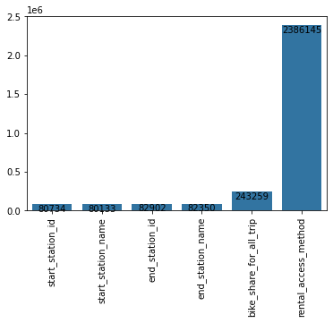

```python
# Create a plot of columns with missing values
baseColor = sb.color_palette()[0]
sb.barplot(x=naCount.index.values, y=naCount, color=baseColor)

plt.xticks(rotation=90)

for i in range(naCount.shape[0]):
    count = naCount[i]

    plt.text(i, count+300, count, ha='center', va='top')

plt.show();
```

Observation:

> rental_access_method column has the least number of non-null values. Data points for this column was only available for 4 (June, July, November & December) out of 12 months, and there were more null values for these months. Since missing values in this column are more than 90% of the entire observations in the dataset, I will drop it.

> There are records for bike_share_for_all_trip in every month, except December. I also observed missing values in June, July and November only. Since there are no records for the month of December I'll keep these rows.

> There are missing records for station ids and station names in 9 out of 12 months. The close number of missing records suggests a relationship: either they are test stations or makeshift stations. However, since these rows wouldn't be useful for my analysis, I will drop them and proceed with further wrangling.

#### Define: Drop rental_access_method column. Drop rows with NaN in start_station_id, start_station_name, end_station_id, end_station_name

#### Code

```python
# Drop rental access method column
bike.drop(columns=['rental_access_method'], inplace=True)

# Drop station related rows with missing values from the dataset
st_id_index = bike[bike.start_station_id.isna()].index
st_name_index = bike[bike.start_station_name.isna()].index
end_id_index = bike[bike.end_station_id.isna()].index
end_name_index = bike[bike.end_station_name.isna()].index

# Combine all index into a master list with unique row numbers
stationIndex = set([*st_id_index, *st_name_index, *end_id_index, *end_name_index])
print(len(stationIndex))

# Drop rows with missing values in start_station_id, start_station_name, end_station_id, and end_station_name
bike.drop(index=stationIndex, inplace=True)
```

```
99724
```

#### Test

```python
bike.info()
```

```
<class 'pandas.core.frame.DataFrame'>
Int64Index: 2407259 entries, 0 to 2506660
Data columns (total 14 columns):
 #   Column                   Dtype
---  ------                   -----
 0   duration_sec             int64
 1   start_time               object
 2   end_time                 object
 3   start_station_id         float64
 4   start_station_name       object
 5   start_station_latitude   float64
 6   start_station_longitude  float64
 7   end_station_id           float64
 8   end_station_name         object
 9   end_station_latitude     float64
 10  end_station_longitude    float64
 11  bike_id                  int64
 12  user_type                object
 13  bike_share_for_all_trip  object
dtypes: float64(6), int64(2), object(6)
memory usage: 275.5+ MB
```

#### Define: Convert start_time and end_time to datetime. Convert start_station_id, end_station_id and bike_id to object. Convert user_type to category type.

#### Code

```python
# Convert start_time and end_time into datetime
timeCol = ['start_time', 'end_time']
for col in timeCol:
    bike[col] = pd.to_datetime(bike[col])
```

```python
# Convert IDs from floats and ints to object data type
strCol = ['start_station_id', 'end_station_id', 'bike_id']
for col in strCol:
    bike[col] = bike[col].astype(str)
```

```python
# Convert User Type to categorical data type
bike.user_type = bike.user_type.astype('category')
```

#### Test

```python
bike.info()
```

```
<class 'pandas.core.frame.DataFrame'>
Int64Index: 2407259 entries, 0 to 2506660
Data columns (total 14 columns):
 #   Column                   Dtype
---  ------                   -----
 0   duration_sec             int64
 1   start_time               datetime64[ns]
 2   end_time                 datetime64[ns]
 3   start_station_id         object
 4   start_station_name       object
 5   start_station_latitude   float64
 6   start_station_longitude  float64
 7   end_station_id           object
 8   end_station_name         object
 9   end_station_latitude     float64
 10  end_station_longitude    float64
 11  bike_id                  object
 12  user_type                category
 13  bike_share_for_all_trip  object
dtypes: category(1), datetime64[ns](2), float64(4), int64(1), object(6)
memory usage: 259.4+ MB
```

```python
bike.describe()
```

|  | duration_sec | start_station_latitude | start_station_longitude | end_station_latitude | end_station_longitude |
| --- | --- | --- | --- | --- | --- |
| count | 2.407259e+06 | 2.407259e+06 | 2.407259e+06 | 2.407259e+06 | 2.407259e+06 |
| mean | 8.048171e+02 | 3.776938e+01 | -1.223547e+02 | 3.776852e+01 | -1.223505e+02 |
| std | 1.910718e+03 | 1.034811e-01 | 1.607865e-01 | 2.244698e-01 | 6.650935e-01 |
| min | 6.000000e+01 | 0.000000e+00 | -1.224952e+02 | 0.000000e+00 | -1.224952e+02 |
| 25% | 3.580000e+02 | 3.777003e+01 | -1.224130e+02 | 3.777041e+01 | -1.224116e+02 |
| 50% | 5.690000e+02 | 3.778053e+01 | -1.223984e+02 | 3.778076e+01 | -1.223981e+02 |
| 75% | 8.830000e+02 | 3.779539e+01 | -1.222948e+02 | 3.779625e+01 | -1.222948e+02 |
| max | 8.623000e+04 | 4.551000e+01 | 0.000000e+00 | 4.551000e+01 | 0.000000e+00 |

### What is the structure of your dataset?

> There are 2,407,259 individual rides in the dataset with 14 features _(duration_sec, start_time, end_time, start_station_id, start_station_name, start_station_latitude, start_station_longitude, end_station_id, end_station_name, end_station_latitude, end_station_longitude, bike_id, user_type, bike_share_for_all*trip)*. Most variables are qualitative in nature but the variables duration_sec, latitudes, and longitudes are numeric, while start and end times are datetime.

### What is/are the main feature(s) of interest in your dataset?

> I'm interested in figuring out what features are best for predicting the duration of bike rides in the dataset.

### What features in the dataset do you think will help support your investigation into your feature(s) of interest?

> I expect that User Type would have the strongest effect on each ride duration: "registered" members have more ride time included in their plan than non-members. I also think that time_of_day, day_of_week, and month will have an effect on ride time but to a lesser degree.

## Univariate Exploration

I'll start by creating new columns for time of day, day of week and month for my analysis.

```python
# Extract time of day, day of week and month columns from start time using pandas dt method
bike['time_of_day'] = bike.start_time.dt.hour
bike['day_of_week'] = bike.start_time.dt.day_name()
bike['month'] = bike.start_time.dt.month_name()
```

```python
# Convert time of day, day of week, and month into cartegorical type
bike['time_of_day'] = bike.time_of_day.astype('category')
bike['day_of_week'] = bike.day_of_week.astype('category')
bike['month'] = bike.month.astype('category')
```

```python
# Convert day of week and into ordinal categorical type
dayOrder = ['Monday', 'Tuesday', 'Wednesday', 'Thursday', 'Friday', 'Saturday', 'Sunday']
monthOrder = ['January','February', 'March', 'April', 'May', 'June',
              'July', 'August', 'September', 'October', 'November', 'December']

bike['day_of_week'] = bike['day_of_week'].cat.set_categories(dayOrder, ordered=True)
bike['month'] = bike['month'].cat.set_categories(monthOrder, ordered=True)
```

```python
# Confirm columns were successfully created and converted into categorical type
bike.info()
```

```
<class 'pandas.core.frame.DataFrame'>
Int64Index: 2407259 entries, 0 to 2506660
Data columns (total 17 columns):
 #   Column                   Dtype
---  ------                   -----
 0   duration_sec             int64
 1   start_time               datetime64[ns]
 2   end_time                 datetime64[ns]
 3   start_station_id         object
 4   start_station_name       object
 5   start_station_latitude   float64
 6   start_station_longitude  float64
 7   end_station_id           object
 8   end_station_name         object
 9   end_station_latitude     float64
 10  end_station_longitude    float64
 11  bike_id                  object
 12  user_type                category
 13  bike_share_for_all_trip  object
 14  time_of_day              category
 15  day_of_week              category
 16  month                    category
dtypes: category(4), datetime64[ns](2), float64(4), int64(1), object(6)
memory usage: 266.3+ MB
```

Question: What is the distribution of the main variable of interest: duration_sec?

```python
bike.duration_sec.shape[0]
```

```
2407259
```

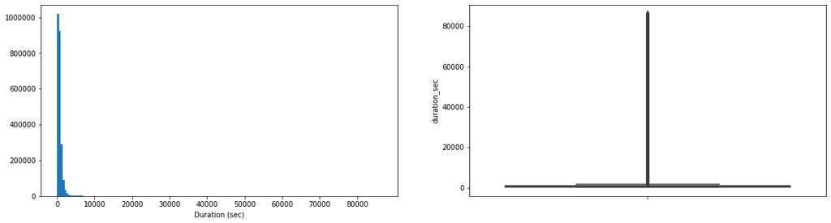

```python
# Start with a standard-scaled plot
plt.figure(figsize=[20, 5])

baseColor = sb.color_palette()[0]

plt.subplot(1,2,1)
binEdges = np.arange(0, bike.duration_sec.max()+500, 500)
plt.hist(data=bike, x='duration_sec', bins=binEdges)
plt.xlabel('Duration (sec)')
plt.ticklabel_format(style='plain')
ticks = [0, 10000, 20000, 30000, 40000, 50000, 60000, 70000, 80000]
labels = ['{}'.format(val) for val in ticks]
plt.xticks(ticks, labels);

plt.subplot(1,2,2)
sb.boxplot(data=bike, y='duration_sec', color=baseColor);

plt.show();
```

The initial plot of duration shows that the plot covers an unexpectedly large range, suggesting some strong outliers to the right that need to be investigated further. It's worth taking some time to identify this outliers and see if they need to be filtered out of the data.

```python
# Get IQR to identify outliers in the duration feature
q1, q3 = np.percentile(bike.duration_sec, [25, 75])
IQR = q3 - q1
#lowerBound = q1 - (IQR * 1.5)
upperBound = q3 + (IQR * 1.5)
upperBound
```

```
1670.5
```

```python
# Filter the outliers using the upper bound of the data points
bike[bike['duration_sec'] > upperBound]
```

|  | duration_sec | start_time | end_time | start_station_id | start_station_name | start_station_latitude | start_station_longitude | end_station_id | end_station_name | end_station_latitude | end_station_longitude | bike_id | user_type | bike_share_for_all_trip | time_of_day | day_of_week | month |
| --- | --- | --- | --- | --- | --- | --- | --- | --- | --- | --- | --- | --- | --- | --- | --- | --- | --- |
| 0 | 80825 | 2019-01-31 17:57:44.613 | 2019-02-01 16:24:49.864 | 229.0 | Foothill Blvd at 42nd Ave | 37.775745 | -122.213037 | 196.0 | Grand Ave at Perkins St | 37.808894 | -122.256460 | 4861 | Subscriber | No | 17 | Thursday | January |
| 1 | 65900 | 2019-01-31 20:58:33.886 | 2019-02-01 15:16:54.173 | 4.0 | Cyril Magnin St at Ellis St | 37.785881 | -122.408915 | 134.0 | Valencia St at 24th St | 37.752428 | -122.420628 | 5506 | Subscriber | No | 20 | Thursday | January |
| 2 | 62633 | 2019-01-31 18:06:52.924 | 2019-02-01 11:30:46.530 | 245.0 | Downtown Berkeley BART | 37.870139 | -122.268422 | 157.0 | 65th St at Hollis St | 37.846784 | -122.291376 | 2717 | Customer | No | 18 | Thursday | January |
| 3 | 44680 | 2019-01-31 19:46:09.719 | 2019-02-01 08:10:50.318 | 85.0 | Church St at Duboce Ave | 37.770083 | -122.429156 | 53.0 | Grove St at Divisadero | 37.775946 | -122.437777 | 4557 | Customer | No | 19 | Thursday | January |
| 4 | 60709 | 2019-01-31 14:19:01.541 | 2019-02-01 07:10:51.065 | 16.0 | Steuart St at Market St | 37.794130 | -122.394430 | 28.0 | The Embarcadero at Bryant St | 37.787168 | -122.388098 | 2100 | Customer | No | 14 | Thursday | January |
| ... | ... | ... | ... | ... | ... | ... | ... | ... | ... | ... | ... | ... | ... | ... | ... | ... | ... |
| 2506620 | 2220 | 2019-12-20 12:49:10.000 | 2019-12-20 13:26:11.000 | 6.0 | The Embarcadero at Sansome St | 37.804770 | -122.403234 | 371.0 | Lombard St at Columbus Ave | 37.802746 | -122.413579 | 439660 | Subscriber | NaN | 12 | Friday | December |
| 2506628 | 3304 | 2019-12-21 12:49:55.000 | 2019-12-21 13:45:00.000 | 6.0 | The Embarcadero at Sansome St | 37.804770 | -122.403234 | 478.0 | Greenwich St at Franklin St | 37.800254 | -122.425919 | 816378 | Subscriber | NaN | 12 | Saturday | December |
| 2506629 | 3997 | 2019-12-29 17:02:41.000 | 2019-12-29 18:09:18.000 | 6.0 | The Embarcadero at Sansome St | 37.804770 | -122.403234 | 6.0 | The Embarcadero at Sansome St | 37.804770 | -122.403234 | 283991 | Subscriber | NaN | 17 | Sunday | December |
| 2506649 | 2064 | 2019-12-27 22:12:12.000 | 2019-12-27 22:46:36.000 | 6.0 | The Embarcadero at Sansome St | 37.804770 | -122.403234 | 21.0 | Montgomery St BART Station (Market St at 2nd St) | 37.789625 | -122.400811 | 402406 | Subscriber | NaN | 22 | Friday | December |
| 2506659 | 1719 | 2019-12-31 10:58:30.000 | 2019-12-31 11:27:10.000 | 6.0 | The Embarcadero at Sansome St | 37.804770 | -122.403234 | 371.0 | Lombard St at Columbus Ave | 37.802746 | -122.413579 | 655789 | Subscriber | NaN | 10 | Tuesday | December |

134194 rows × 17 columns

The are 134,194 rows with outliers which all seem to be valid data points. As a final outlier check, since 'duration_sec' is the difference between start_time and end_time, we can see if any rows contain inaccurate values.

```python
outliers = []
for x, y in zip(bike.start_time, bike.end_time):
    secs = (y-x).seconds
    outliers.append(secs)

bike['time_diff'] = outliers
```

```python
bike.query('duration_sec != time_diff')
```

|  | duration_sec | start_time | end_time | start_station_id | start_station_name | start_station_latitude | start_station_longitude | end_station_id | end_station_name | end_station_latitude | end_station_longitude | bike_id | user_type | bike_share_for_all_trip | time_of_day | day_of_week | month | time_diff |
| --- | --- | --- | --- | --- | --- | --- | --- | --- | --- | --- | --- | --- | --- | --- | --- | --- | --- | --- |
| 567839 | 78403 | 2019-03-09 14:01:37.602 | 2019-03-10 12:48:21.535 | 44.0 | Civic Center/UN Plaza BART Station (Market St ... | 37.781074 | -122.411738 | 21.0 | Montgomery St BART Station (Market St at 2nd St) | 37.789625 | -122.400811 | 6576 | Customer | No | 14 | Saturday | March | 82003 |
| 567898 | 38028 | 2019-03-10 01:06:50.626 | 2019-03-10 12:40:39.498 | 31.0 | Raymond Kimbell Playground | 37.783813 | -122.434559 | 4.0 | Cyril Magnin St at Ellis St | 37.785881 | -122.408915 | 5223 | Subscriber | No | 1 | Sunday | March | 41628 |
| 568012 | 65865 | 2019-03-09 17:02:18.785 | 2019-03-10 12:20:04.356 | 323.0 | Broadway at Kearny | 37.798014 | -122.405950 | 371.0 | Lombard St at Columbus Ave | 37.802746 | -122.413579 | 6327 | Customer | No | 17 | Saturday | March | 69465 |
| 568505 | 38707 | 2019-03-09 22:55:48.837 | 2019-03-10 10:40:55.916 | 124.0 | 19th St at Florida St | 37.760447 | -122.410807 | 398.0 | Leavenworth St at Broadway | 37.796471 | -122.416858 | 6545 | Customer | No | 22 | Saturday | March | 42307 |
| 568509 | 39505 | 2019-03-09 22:41:16.199 | 2019-03-10 10:39:41.682 | 341.0 | Fountain Alley at S 2nd St | 37.336188 | -121.889277 | 310.0 | San Fernando St at 4th St | 37.335885 | -121.885660 | 4043 | Subscriber | Yes | 22 | Saturday | March | 43105 |
| ... | ... | ... | ... | ... | ... | ... | ... | ... | ... | ... | ... | ... | ... | ... | ... | ... | ... | ... |
| 2506650 | 380 | 2019-12-27 09:05:32.000 | 2019-12-27 09:11:53.000 | 6.0 | The Embarcadero at Sansome St | 37.804770 | -122.403234 | 22.0 | Howard St at Beale St | 37.789756 | -122.394643 | 892636 | Subscriber | NaN | 9 | Friday | December | 381 |
| 2506654 | 395 | 2019-12-20 11:46:05.000 | 2019-12-20 11:52:41.000 | 6.0 | The Embarcadero at Sansome St | 37.804770 | -122.403234 | 15.0 | San Francisco Ferry Building (Harry Bridges Pl... | 37.795392 | -122.394203 | 600130 | Subscriber | NaN | 11 | Friday | December | 396 |
| 2506658 | 1581 | 2019-12-31 20:16:15.000 | 2019-12-31 20:42:37.000 | 6.0 | The Embarcadero at Sansome St | 37.804770 | -122.403234 | 50.0 | 2nd St at Townsend St | 37.780526 | -122.390288 | 882336 | Subscriber | NaN | 20 | Tuesday | December | 1582 |
| 2506659 | 1719 | 2019-12-31 10:58:30.000 | 2019-12-31 11:27:10.000 | 6.0 | The Embarcadero at Sansome St | 37.804770 | -122.403234 | 371.0 | Lombard St at Columbus Ave | 37.802746 | -122.413579 | 655789 | Subscriber | NaN | 10 | Tuesday | December | 1720 |
| 2506660 | 368 | 2019-12-23 17:13:43.000 | 2019-12-23 17:19:52.000 | 6.0 | The Embarcadero at Sansome St | 37.804770 | -122.403234 | 15.0 | San Francisco Ferry Building (Harry Bridges Pl... | 37.795392 | -122.394203 | 119878 | Subscriber | NaN | 17 | Monday | December | 369 |

11027 rows × 18 columns

```python
bike.duration_sec = bike.time_diff
```

```python
bike.query('duration_sec != time_diff')
```

|  | duration_sec | start_time | end_time | start_station_id | start_station_name | start_station_latitude | start_station_longitude | end_station_id | end_station_name | end_station_latitude | end_station_longitude | bike_id | user_type | bike_share_for_all_trip | time_of_day | day_of_week | month | time_diff |
| --- | --- | --- | --- | --- | --- | --- | --- | --- | --- | --- | --- | --- | --- | --- | --- | --- | --- | --- |

```python
bike.drop(columns='time_diff', inplace=True)
```

This check showed data points with inaccurate information (which I have handled above), but the outliers in this feature are confirmed to be valid. However, I'll remove all outliers from the dataset to ensure they don't add noise or negatively bias the result of my analysis.

```python
bikeOutlier = bike[bike['duration_sec'] > upperBound]
outIndex = bikeOutlier.index
```

```python
# Drop outliers from the duration feature
bike.drop(index=outIndex, inplace=True)
```

```python
bike[bike.duration_sec >= upperBound]
```

|  | duration_sec | start_time | end_time | start_station_id | start_station_name | start_station_latitude | start_station_longitude | end_station_id | end_station_name | end_station_latitude | end_station_longitude | bike_id | user_type | bike_share_for_all_trip | time_of_day | day_of_week | month |
| --- | --- | --- | --- | --- | --- | --- | --- | --- | --- | --- | --- | --- | --- | --- | --- | --- | --- |

#### Store Data

```python
filePath = 'C:/datasets'
fileName = 'bike_sharing_clean.csv'
fullFileDir = filePath + '/' + fileName
bike.to_csv(fullFileDir, index=False)
```

Question: What are the underlying patterns in the data?

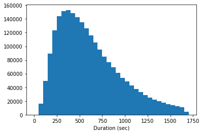

```python
plt.ticklabel_format(style='plain')

binEdges = np.arange(0, bike.duration_sec.max()+50, 50)
plt.hist(data=bike, x='duration_sec', bins=binEdges)
plt.xlabel('Duration (sec)');

plt.show();
```

Duration has a long-tailed distribution, with a lot of trips on the short duration end, and a few on the long duration end. When plotted after removing outliers, duration is unimodal and right-skewed with a peak around 300 secs.

Question: How is user_type distributed?

[figure not shown]

```python
userTypeCount = bike.user_type.value_counts()
userLabel = bike.user_type.value_counts().index
plt.pie(userTypeCount, labels=userLabel, startangle=90, counterclock=False, wedgeprops={'width':0.5}, autopct='%1.1f%%')

plt.axis('square')
#plt.xlabel('user_type')

chartLabel('Duration (sec)', 'Count', 'Distribution of Ride Duration')
plt.show();
```

The most common individual rides are bike trips by registered members.

Question: How are the trips distributed in terms of time of day, day of week and month of year?

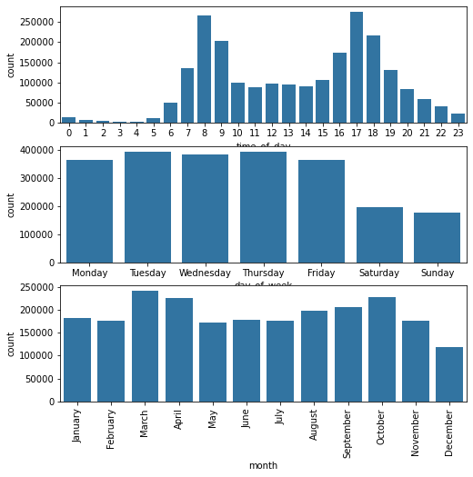

```python
# Let's plot all three variables together to get an idea of each variables distribution
fig, ax= plt.subplots(nrows=3, figsize = [8, 8])
sb.countplot(data=bike, x='time_of_day', color=baseColor, ax=ax[0]);
sb.countplot(data=bike, x='day_of_week', color=baseColor, ax=ax[1]);
sb.countplot(data=bike, x='month', color=baseColor, ax=ax[2])
plt.xticks(rotation=90);

plt.show();
```

The plots of show immediate silmilarities between time of day, day of week and month: most trips are taken during weekdays in periods leading to or following official working hours, and in months that fall into seasons with favorable weather conditions. It's likely these variables have a correlation with user type.

I'll now look at the remaining features in the dataset to see if they hold interesting properties

What are the most popular stations?

```python
startStat = bike.start_station_name.value_counts().head(10)
endStat = bike.end_station_name.value_counts().head(10)
```

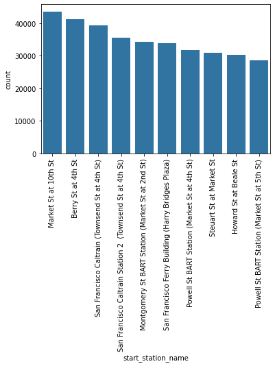

```python
sb.barplot(startStat.index, startStat, color=baseColor)
plt.xticks(rotation=90)
plt.xlabel('start_station_name')
plt.ylabel('count');
```

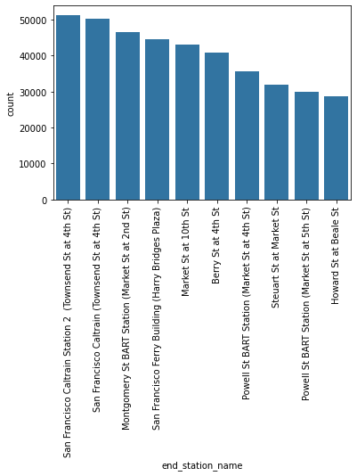

```python
sb.barplot(endStat.index, endStat, color=baseColor)
plt.xticks(rotation=90)
plt.xlabel('end_station_name')
plt.ylabel('count');
```

Interestingly, stations around other transport services like rail and ferry are among the most popular start and end station for bike trips.

### Discuss the distribution(s) of your variable(s) of interest. Were there any unusual points? Did you need to perform any transformations?

> The duration variable took on a very large range, so I validated the outliers and dropped them. Without the previous outliers, the data looked unimodal, with a peak just around 300 secs.

### Of the features you investigated, were there any unusual distributions? Did you perform any operations on the data to tidy, adjust, or change the form of the data? If so, why did you do this?

> I performed operations to change the form of start_time to create new columns (time_of_day, day_of_week, month) which would make result of analysis clearer.

## Bivariate Exploration

> To start off, I want to look at the pairwise correlation between our feature of interest (duration) and categorical features in the data. I will use violin plots and box plots to visualize the summary statistics and the nuance of the data.

What's the relationship between duration and user_type?

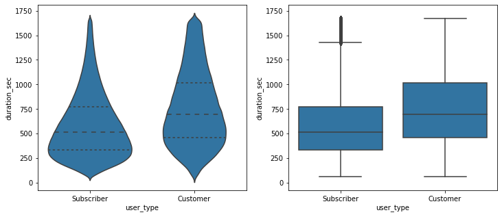

```python
plt.figure(figsize=[12, 5])
baseColor = sb.color_palette()[0]

plt.subplot(1,2,1)
ax = sb.violinplot(data=bike, x='user_type', y='duration_sec', color=baseColor, inner='quartile', order=['Subscriber', 'Customer']);

plt.subplot(1,2,2)
sb.boxplot(data=bike, x='user_type', y='duration_sec', color=baseColor, order=['Subscriber', 'Customer'])
plt.ylim(ax.get_ylim());

plt.show();
```

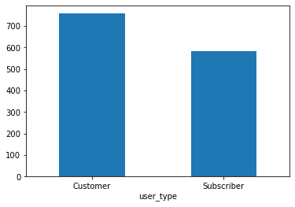

```python
# Visualize the mean duration of trips by subscribers and customers
bike.groupby('user_type')['duration_sec'].mean().plot(kind='bar')
plt.xticks(rotation=0);
```

The boxplot element shows that the median duration for trips taken by subscribers is lower than that of customers. The shape of the distribution in violin plot shows that the duration of subscriber trips is concentrated around the first quartile range while customers have a more seemingly distribution.

What's the relationship between duration and day of week?

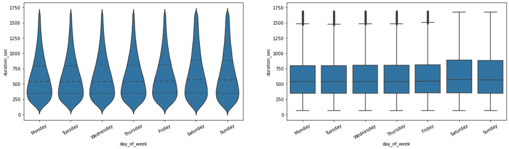

```python
plt.figure(figsize=[20, 5])
baseColor = sb.color_palette()[0]

plt.subplot(1,2,1)
ax = sb.violinplot(data=bike, x='day_of_week', y='duration_sec', color=baseColor, inner='quartile')
plt.xticks(rotation=30);

plt.subplot(1,2,2)
sb.boxplot(data=bike, x='day_of_week', y='duration_sec', color=baseColor)
plt.xticks(rotation=30)
plt.ylim(ax.get_ylim());

plt.show();
```

The relationship between the plotted variables shows a consistent pattern. Weekdays tend to have bike trips that lasts for a shorter duration while trips at the weekend last longer. The boxplot makes it easier to see that there is more variance in duration at the weekends.

What is the relationship between duration and month?

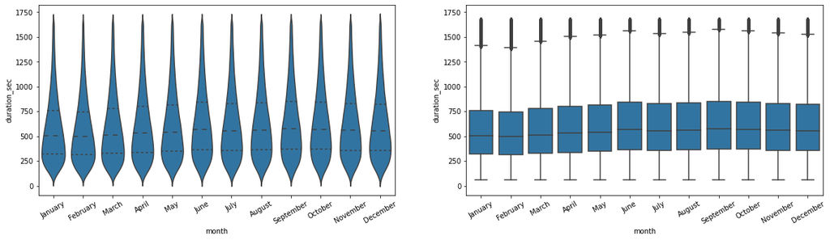

```python
plt.figure(figsize=[20, 5])
baseColor = sb.color_palette()[0]

plt.subplot(1,2,1)
ax = sb.violinplot(data=bike, x='month', y='duration_sec', color=baseColor, inner='quartile')
plt.xticks(rotation=30);

plt.subplot(1,2,2)
sb.boxplot(data=bike, x='month', y='duration_sec', color=baseColor)
plt.xticks(rotation=30);
plt.ylim(ax.get_ylim());

plt.show();
```

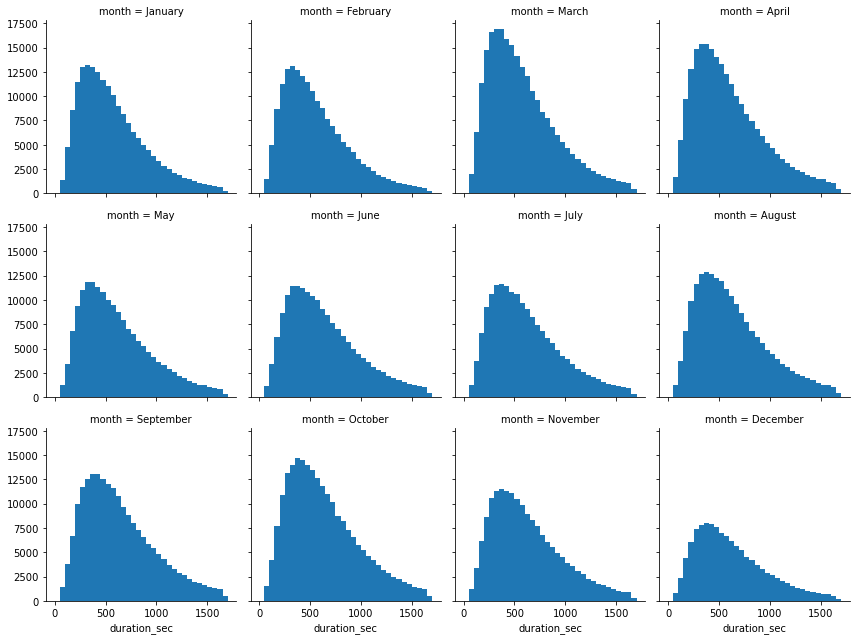

```python
g = sb.FacetGrid(data=bike, col='month', col_wrap=4)
g.map(plt.hist, 'duration_sec', bins=binEdges);
```

What's the relationship between time of day and duration?

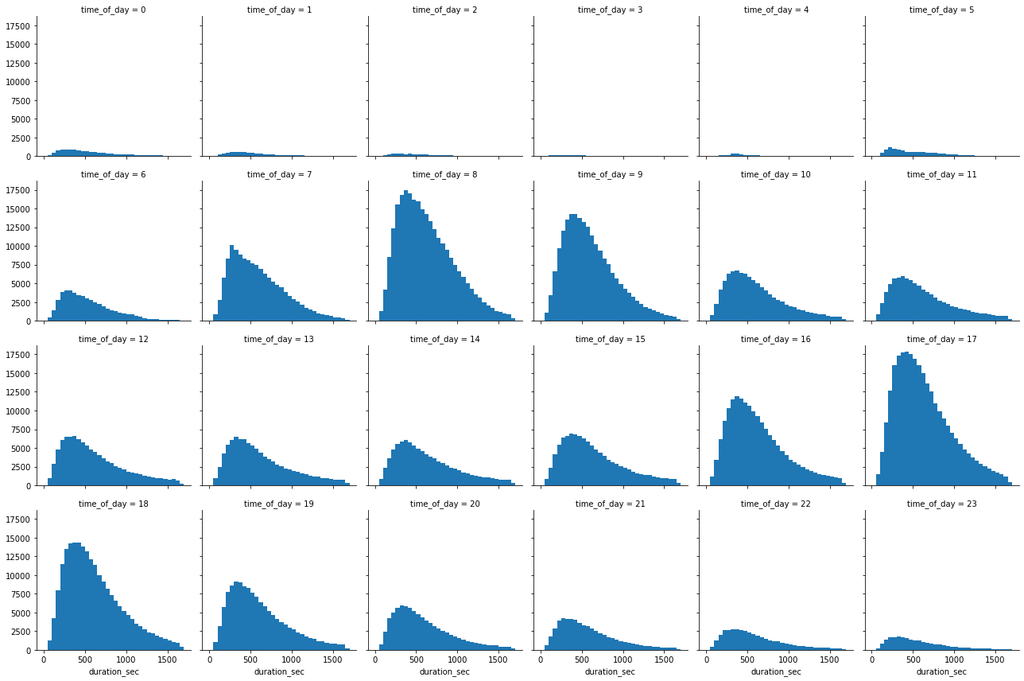

```python
g = sb.FacetGrid(data=bike, col='time_of_day', col_wrap=6)
g.map(plt.hist, 'duration_sec', bins=binEdges);
```

I used faceting to divide the data into disjoint subsets. The distribution remained consistent across all time of day with most trips lasting in the lower end of duration.

What is the relationship between day of week and user type?

```python
# Create function to plot clustered barchart for user type vs period variables
def clustered_bar(xa):
    """
    xa = str(variable to be plotted on x-axis)
    """
    sb.countplot(data=bike, x=xa, hue='user_type')
    plt.xticks(rotation=15)
    plt.show();
```

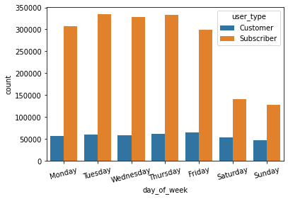

```python
clustered_bar('day_of_week')
```

The plot shows a relationship opposite that of day of week and duration. While trips at the weekend lasted for a longer duration, there's a decline in the number of subscribers and customers who took trips at the weekend. The relationship between these variables will be investigated further in the next section.

What's the relationship between month and user_type?

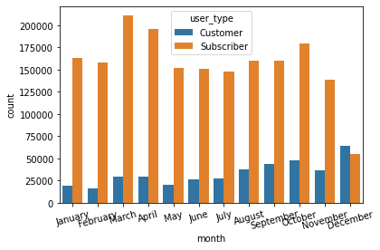

```python
clustered_bar('month')
```

Interestingly, subscribers remained the most active user type except in December when there were more individual trips by customers.

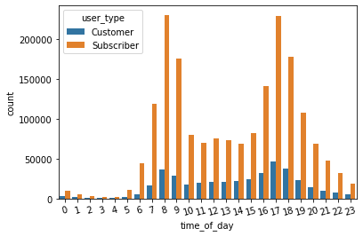

```python
clustered_bar('time_of_day')
```

### Talk about some of the relationships you observed in this part of the investigation. How did the feature(s) of interest vary with other features in the dataset?

> There was an interesting relationship between duration and user type. While member plans have more ride time, subscriber trips usually lasted for a shorter duration with a concentration around 300 secs. For all of, time of day, day of week, and month, duration showed a consistent pattern.

### Did you observe any interesting relationships between the other features (not the main feature(s) of interest)?

> Expected relationships were found in the association between user type and the period variables (time of day, day of week, and month). However, the count of trips taken by customers remained around the same level during weekdays and weekends. Interestingly, December is the only month with more customer bike rides than that of subscribers.

## Multivariate Exploration

> The main thing I want to explore in this part of the analysis is the association between duration, user type, and the period variables.

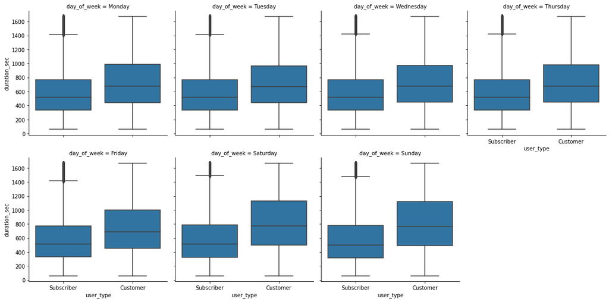

```python
#Create a faceted boxplot on levels of day of week variable
g = sb.FacetGrid(data=bike, col='day_of_week', col_wrap=4, height=4)
g.map(sb.boxplot, 'user_type', 'duration_sec', order=['Subscriber', 'Customer']);
```

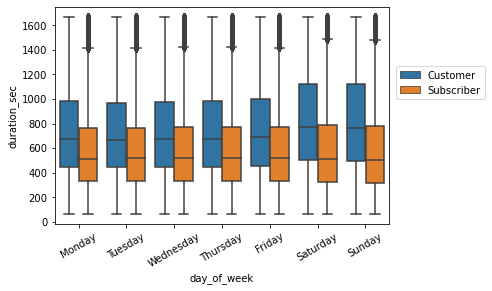

```python
# Create adaptation of clustered bar chart to clearly see relationship
ax = sb.boxplot(data=bike, x='day_of_week', y='duration_sec', hue='user_type');
plt.xticks(rotation=30)
plt.legend(bbox_to_anchor=(1.3, 0.75));
```

The plots clearly show the disparity in ride duration among user types. This disparity in duration is higher on weekends.

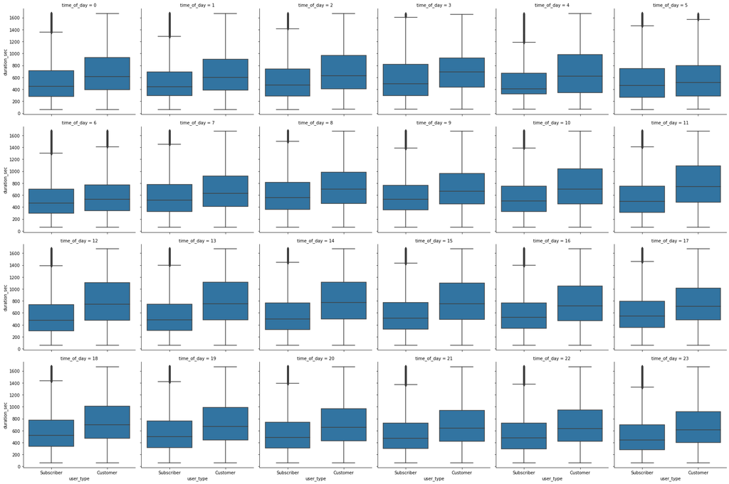

```python
#Create a faceted boxplot on levels of time of day variable
g = sb.FacetGrid(data=bike, col='time_of_day', col_wrap=6, height=4)
g.map(sb.boxplot, 'user_type', 'duration_sec', order=['Subscriber', 'Customer']);
```

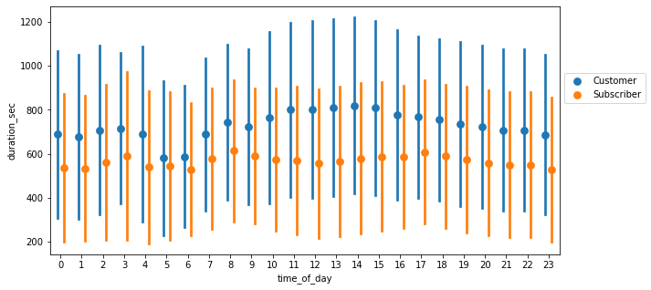

```python
# Create adaptation of point plot to clearly see relationship
plt.figure(figsize=[10, 5])
ax = sb.pointplot(data=bike, x='time_of_day', y='duration_sec', hue='user_type', dodge=0.3, ci='sd', size=5, linestyles='');
#plt.xticks(rotation=30)
plt.legend(bbox_to_anchor=(1, 0.75));
```

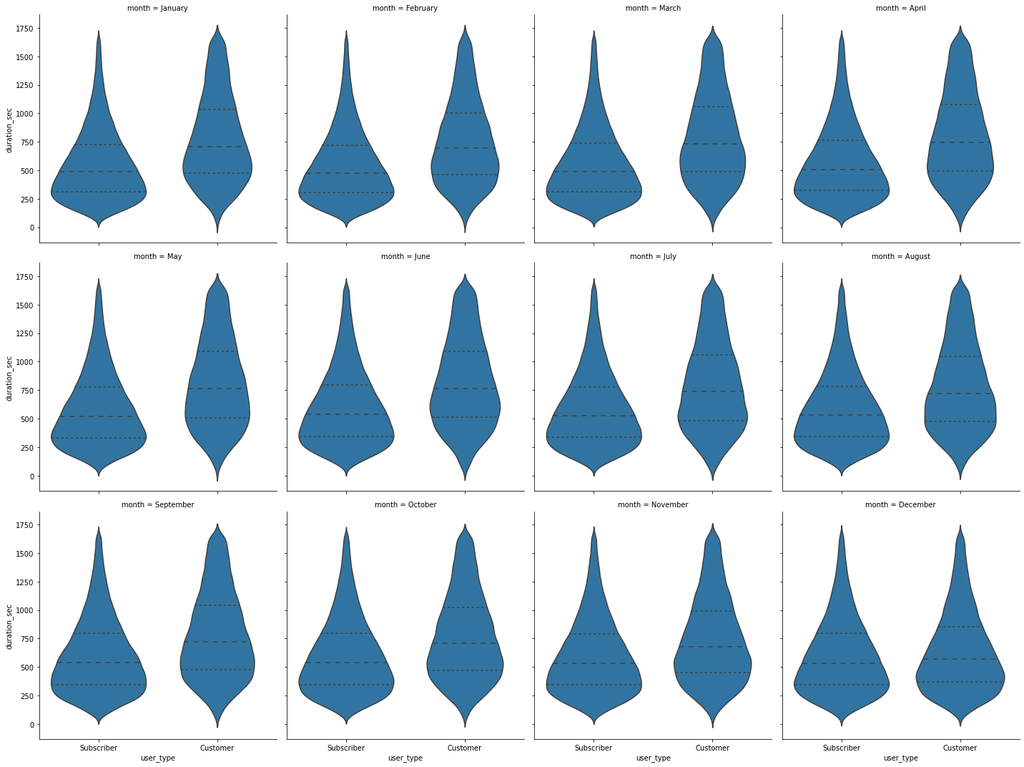

```python
#Create a faceted violinplot on levels of time of day variable
g = sb.FacetGrid(data=bike, col='month', col_wrap=4, height=5)
g.map(sb.violinplot, 'user_type', 'duration_sec', inner='quartile', order=['Subscriber', 'Customer']);
```

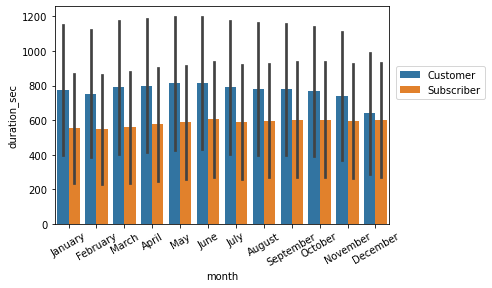

```python
# Create adaptation of clustered bar chart to clearly see relationship
ax = sb.barplot(data=bike, x='month', y='duration_sec', hue='user_type', ci='sd');
plt.xticks(rotation=30)
plt.legend(bbox_to_anchor=(1.3, 0.75));
```

The plots show that ride duration steadily rise from March to June. The violin plot shows that trips lasted a shorter duration and closely mirrored the range of trips by subscribers.

### Talk about some of the relationships you observed in this part of the investigation. Were there features that strengthened each other in terms of looking at your feature(s) of interest?

> I extended my investigation of duration_sec against user type in this section by looking at the impact of the period feature. The multivariate exploration here showed that indeed there is an effect of user type on ride duration. This was initially hidden in the dataset due to the fact that Subscribers, who had the largest share of trips, have individual rides that lasted for a short duration overall.

### Were there any interesting or surprising interactions between features?

> Also, Customers had bike rides for short duration, similar to that of subscribers, in December. This might be connected with an increased amount of time spent indoors due to the festivities in that period.

## Conclusions

> To make the dataset ready for exploration, it required that I performed some data wrangling. I gathered the dataset by downloading separated tables programmatically, I merged all into a master dataset for a full year coverage, assessed and then cleaned highlighted issues. Afterwards, I began exploratory analysis operations on the dataset and made the following findings:
> 1. The duration of an average trip is strongly associated with if a user is a subscriber or a customer. Subscribers tend to take more trips with short durations of around 300 seconds with only few lasting for longer duration.
> 2. Bike are a functional utility for Subscribers due to the consistent pattern seen in trip duration during working hours, work days, and months with more work days. The popular start and end stations were fairly consistent suggesting frequent trips between these stations.
> 3. Most trips are taken during weekdays and in the hours leading to and following the official working hours. Bike rides were also slightly dependent on seasonal trends with most trips (and an increased duration) observed in the spring.

> The exploration depicts that the bike scheme is a preffered means of commute for Subscribers who are mainly locals/residents of the greater San Francisco Bay Area.